# Sec_GCN_gtex

Amy Hicks

16/12/2021

This markdown contains an exploration of the secondary coexpression networks from [Sanchez et al., 2021](https://academic.oup.com/bioinformatics/advance-article/doi/10.1093/bioinformatics/btab175/6178279). Four networks were created from frontal cortex tissue data from the **GTEx dataset** and categorised by the correction or **removal of the effect** of specific cell types, namely **neurons, mature astrocytes, microglia** and **oligodendrocytes**. Several lists of genes of interest were searched within these networks to investigate the effect of cell type on gene co-expression relationships.

```r
# First initialise the datasets/packages to use
CoExpGTEx::initDb(mandatory = T)
```

# 1. Gene lists of interest

## 1.1. NSL complex genes

Firstly, the nine genes encoding the NSL complex will be focused on [(Sheikh et al., 2019)](https://www.ncbi.nlm.nih.gov/pmc/articles/PMC6607013/). These genes encode proteins which make up an **acetyltransferase complex** linked to both nuclear and mitochondrial gene expression.

```r
# Load list
NSL_list <- read.delim(file.path(here::here("data", "Gene_lists", "NSL_list.txt")))
# Make gene/ENSG lists
NSL_genes <- as.character(NSL_list$Gene_symbol)
NSL_ENSG <- as.character(NSL_list$Ensembl_ID)
```

The number of genes in this list: **9**.

## 1.2. PD mendelian

A lis1t of highly penetrant genes linked to familial forms of Parkinson's disease was obtained from PanelApp [Parkinson disease and complex Parkinsonism version 1.68](https://panelapp.genomicsengland.co.uk/panels/39/), a list collected and validated by a group of experts.

```r
# Load list
PD_mendelian_list <- read.delim(file.path(here::here("data", "Gene_lists", "PD_mendelian_list.txt")))
# Make gene/ENSG lists
PD_mendelian_genes <- as.character(PD_mendelian_list$Gene_symbol)
PD_mendelian_ENSG <- as.character(PD_mendelian_list$Ensembl_ID)
```

The number of genes in this list: **43**.

## 1.3. PD sporadic

A list of less penetrant, more common genes linked to sporadic Parkinson's disease was obtained from the latest GWAS, described as *"Of the genes possibly associated with at least one QTL in public reference datasets and therefore testable via summary-based Mendelian randomisation, the expression or methylation of 64% was significantly associated with a possible causal change in Parkinson's disease risk."*

```r
# Load list
PD_GWAS_list <- read.delim(file.path(here::here("data", "Gene_lists", "PD_GWAS_list.txt")))
# Make gene/ENSG lists
PD_GWAS_genes <- as.character(PD_GWAS_list$Gene_symbol)
PD_GWAS_ENSG <- as.character(PD_GWAS_list$Ensembl_ID)
```

The number of genes in this list is: **150**.

# 2. Useful info from primary network

Some information from the primary gene co-expression network was compared to results from secondary gene co-expression networks.

```r
# Load enrichments from CoExp and GMSCA source files
gtex_net <- readRDS(file.path(here::here("data", "CoExp_source", "netFCortex.9.it.50.rds")))
gtex_enrich <- as.data.frame(
  getModulesEnrichment(
    gtex_net,
    markers.path = file.path(here::here("data", "GMSCA_source", "markers"))
    )
  )
# Search NSL genes in primary network
NSL_report_gt <- reportOnGenes(tissue = "FCortex",
                               genes = NSL_genes,
                               which.one = "gtexv6",
                               ens.correction = c("ENSG00000257382", "ENSG00000120071"))
NSL_rep_gt <- NSL_report_gt$report
NSL_mods <- as.character(unique(NSL_rep_gt$module))
gtex_enrich_NSL <- dplyr::select(gtex_enrich, one_of(NSL_mods))
```

# 3. Neuron network

The overall structure of the network was first examined.

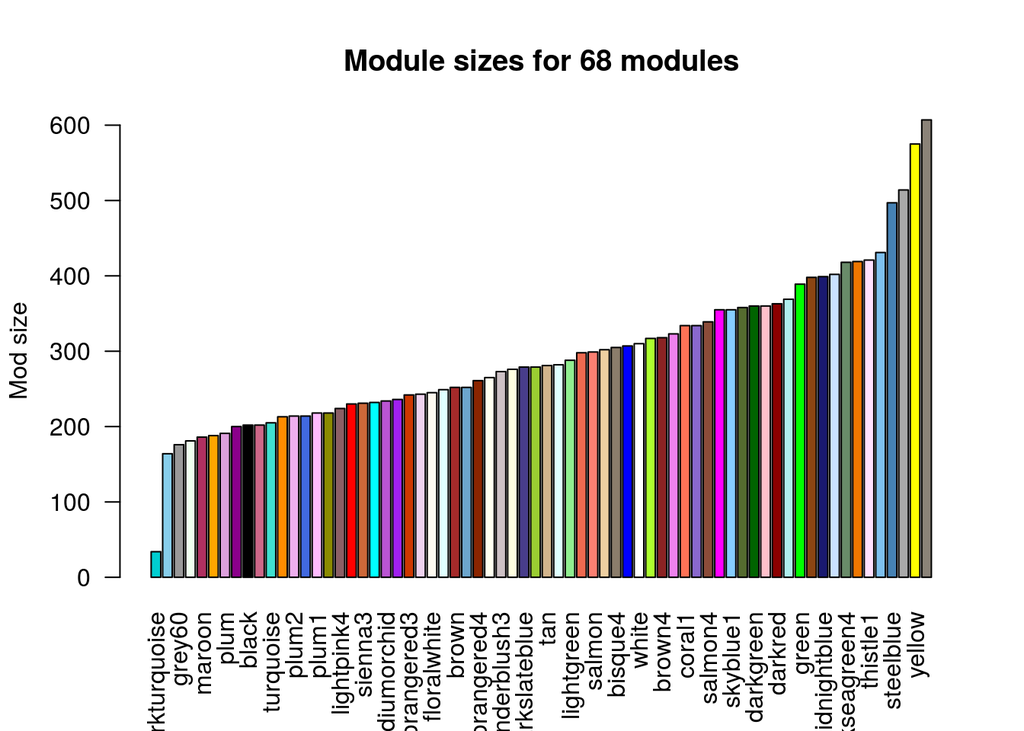

```r
# Load network
N_net = readRDS(file.path(here::here("data", "Networks", "netFCortex.9.it.50.rds.No.N.rds")))
# Plot sizes of modules
CoExpNets::plotModSizes(tissue = N_net, which.one = "new")
```

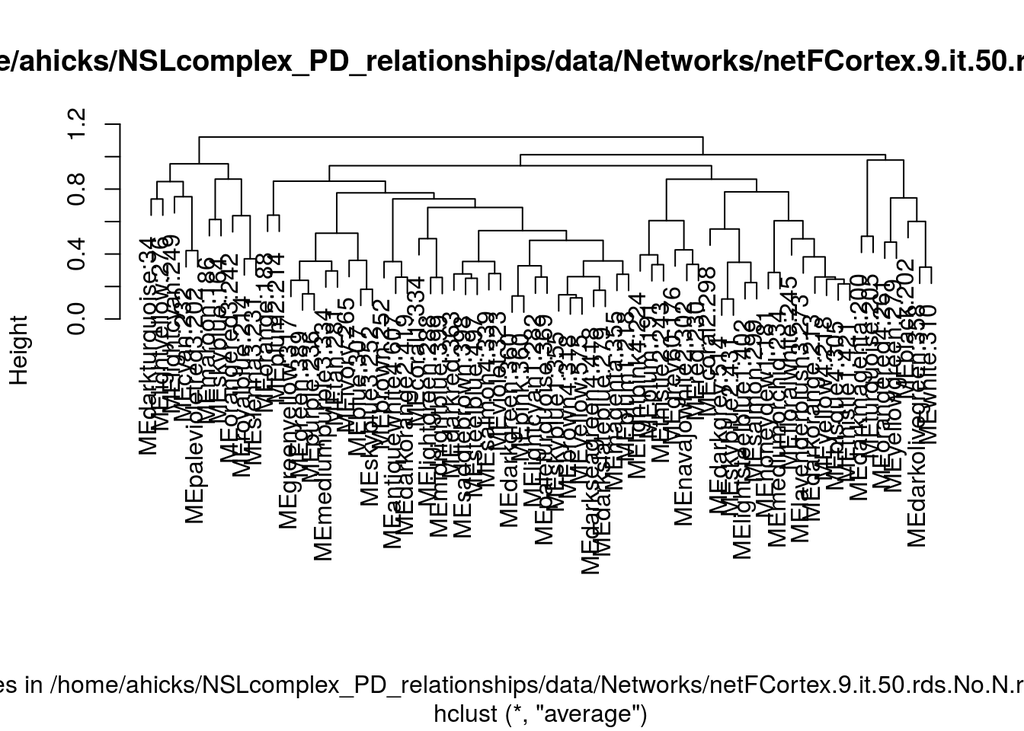

```r
# Obtain eigengenes for each module
N_net.name <- file.path(here::here("data", "Networks", "netFCortex.9.it.50.rds.No.N.rds"))
N_egs <- CoExpNets::getNetworkEigengenes(tissue = N_net.name, which.one = "new")
# Plot eigengene clustering
CoExpNets::plotEGClustering(tissue = N_net.name, which.one = "new")
```

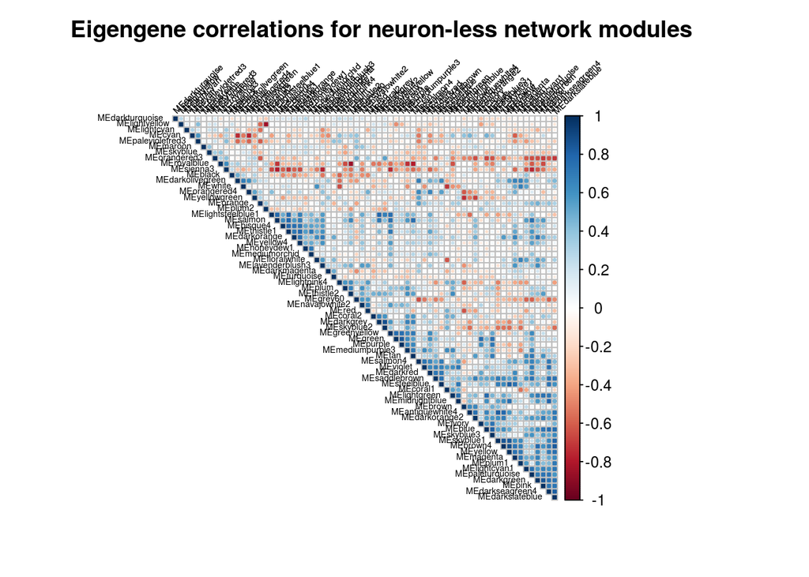

```r
# Plot correlation between modules
corrplot(cor(N_egs), tl.srt = 45,
         tl.col = "black",
         type = "upper",
         tl.cex = 0.45,
         order = "hclust",
         title = paste0("Eigengene correlations for neuron-less network modules"),
         mar = c(3, 2, 2.5, 4))
```

## 3.1. Searching gene lists

### NSL genes

First the genes encoding the NSL complex were searched.

```r
# Search genes in network
N_NSL_mod <- as.data.frame(CoExpNets::reportOnFETGenes(tissue = N_net.name, genes = NSL_ENSG, which.one = "new", net = NULL))
N_NSL_mod <- tibble::rownames_to_column(N_NSL_mod, "ENSG")
N_NSL_mod <- dplyr::select(N_NSL_mod, ENSG, module, p.val.mods)
N_NSL_mod$Gene <- N_NSL_mod$ENSG
# Add gene symbols
for (i in NSL_list$Ensembl_ID) {
  loc <- match(i, NSL_list$Ensembl_ID)
  N_NSL_mod$Gene[N_NSL_mod$Gene== i] <- NSL_list$Gene_symbol[loc]
}
# Get module membership
N_MM <- as.data.frame(N_net$MM)
colnames(N_MM)<- "MM"
N_MM <- rownames_to_column(N_MM, "ENSG")
N_MM$MM <- signif(N_MM$MM, 4)
# Add MM to table
N_NSL_mod$MM <- N_NSL_mod$ENSG
for (i in N_MM$ENSG) {
  loc <- match(i, N_MM$ENSG)
  N_NSL_mod$MM[N_NSL_mod$MM== i] <- N_MM$MM[loc]
}
# Reorder table
N_NSL_mod <- N_NSL_mod[,c(4,1,5,2,3)]
N_NSL_mod <- dplyr::arrange(N_NSL_mod, p.val.mods)
# Store NSL enriched modules
N_NSL_modules <- unique(N_NSL_mod$module)
# Print result
N_NSL_mod
```

| Gene | ENSG | MM | module | p.val.mods |
| --- | --- | --- | --- | --- |
| KANSL1 | ENSG00000120071 | 0.7925 | darkslateblue | 0.006458 |
| OGT | ENSG00000147162 | 0.8582 | darkslateblue | 0.006458 |
| PHF20 | ENSG00000025293 | 0.8699 | brown4 | 0.1335 |
| KANSL3 | ENSG00000114982 | 0.8306 | violet | 0.1355 |
| KAT8 | ENSG00000103510 | 0.7377 | salmon4 | 0.1417 |
| HCFC1 | ENSG00000172534 | 0.8497 | skyblue1 | 0.148 |
| KANSL2 | ENSG00000139620 | 0.7793 | darkgreen | 0.1499 |
| WDR5 | ENSG00000196363 | 0.9049 | yellow | 0.2296 |
| MCRS1 | ENSG00000187778 | 0.5834 | antiquewhite4 | 0.2408 |

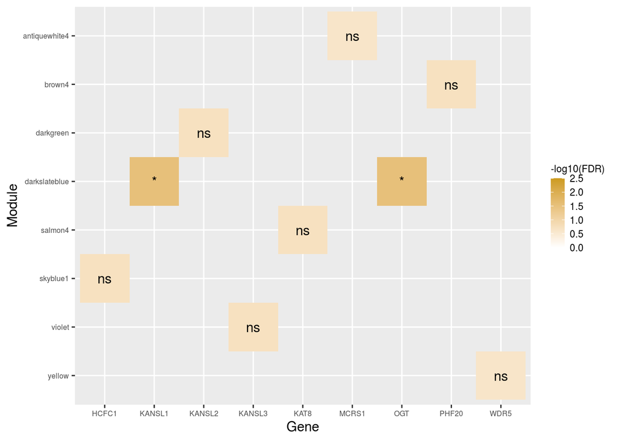

```r
# Format dataframe for figure
N_NSL_mod$FDR <- p.adjust(N_NSL_mod$p.val.mods, method = "fdr")
names(N_NSL_mod)[names(N_NSL_mod)=="p.val.mods"] <- "p.val"
names(N_NSL_mod)[names(N_NSL_mod)=="module"] <- "Module"
N_NSL_mod$p.val <- as.numeric(N_NSL_mod$p.val)
N_NSL_mod <- dplyr::arrange(N_NSL_mod, Module)
N_NSL_mod$position <- nrow(N_NSL_mod):1
N_NSL_mod$`-log10(p.val)` <- -log10(N_NSL_mod$p.val)
N_NSL_mod$`-log10(FDR)` <- -log10(N_NSL_mod$FDR)
# Produce plot
source(file.path(here::here("scripts", "CoExp_functions.R")))
ggplot(N_NSL_mod, aes(Gene, reorder(Module, position))) +
  geom_tile(aes(fill = `-log10(FDR)`)) +
  geom_text(aes(label = signif.num(FDR))) +
  scale_fill_gradient(low = "white", high = "goldenrod3", limits = c(0,2.5)) +
  labs(y = "Module", x = "Gene") +
  theme(
    axis.text = element_text(size = 6),
    legend.title = element_text(size = 8),
    legend.text = element_text(size = 8),
    legend.key.size = unit(4, "mm"))
```

The total number of genes in the output table was **9**, indicating there were **0** genes missing from the search. These genes appeared in 8 modules, each of which was examined for **enrichment** of cell type specific markers.

```r
# Load cell type markers enriched for each module
N_mod_enrich <- as.data.frame(getModulesEnrichment(N_net,
                                                   markers.path = file.path(here::here("data", "GMSCA_source", "markers"))))
# Filter enrichments for NSL modules
N_mod_enrich_NSL <- dplyr::select(N_mod_enrich, one_of(N_NSL_modules))
```

The modules containing NSL genes showed **no significant enrichment** for **any cell types**.

```r
# Compare changes in enrichments
N_changes <- enrichmentEvolution(gtex_net,
                                 N_net,
                                 genes = NSL_ENSG,
                                 markers.path = file.path(here::here("data", "GMSCA_source", "markers")))
N_changes$ENSG <- as.character(N_changes$gene)
for (i in NSL_list$Ensembl_ID) {
  loc <- match(i, NSL_list$Ensembl_ID)
  N_changes$gene[N_changes$gene == i] <- NSL_list$Gene_symbol[loc]
}
```

The cell type enrichments were compared to that of the **primary** coexpression network.

```r
N_changes[,c(1,2,3,4,5)]
```

| gene | primary.module | primary.enrichment | secondary.module | secondary.enrichment |
| --- | --- | --- | --- | --- |
| HCFC1 | red | - | skyblue1 | - |
| KANSL1 | red | - | darkslateblue | - |
| KANSL2 | greenyellow | - | darkgreen | - |
| KANSL3 | magenta | - | violet | - |
| KAT8 | darkred | Neuron_Dopaminergic, Neuron_DopaminergicNeuron | salmon4 | - |
| MCRS1 | darkred | Neuron_Dopaminergic, Neuron_DopaminergicNeuron | antiquewhite4 | - |
| OGT | red | - | darkslateblue | - |
| PHF20 | grey60 | - | brown4 | - |
| WDR5 | red | - | yellow | - |

The modules containing NSL genes showed **no significant enrichment** for **any cell types**.

### PD mendelian genes

The results tables for the PD mendelian gene list were filtered for the 8 modules containing NSL genes.

```r
# Search genes in network
N_PD_mendelian_mod <- as.data.frame(CoExpNets::reportOnFETGenes(tissue = N_net.name,
                                                                genes = PD_mendelian_ENSG,
                                                                which.one = "new",
                                                                net = NULL))
N_PD_mendelian_mod <- tibble::rownames_to_column(N_PD_mendelian_mod, "ENSG")
N_PD_mendelian_mod <- dplyr::select(N_PD_mendelian_mod, ENSG, module, p.val.mods)
N_PD_mendelian_mod$Gene <- N_PD_mendelian_mod$ENSG
# Add gene symbols
for (i in PD_mendelian_list$Ensembl_ID) {
  loc <- match(i, PD_mendelian_list$Ensembl_ID)
  N_PD_mendelian_mod$Gene[N_PD_mendelian_mod$Gene== i] <- PD_mendelian_list$Gene_symbol[loc]
}
# Add MM to table
N_PD_mendelian_mod$MM <- N_PD_mendelian_mod$ENSG
for (i in N_MM$ENSG) {
  loc <- match(i, N_MM$ENSG)
  N_PD_mendelian_mod$MM[N_PD_mendelian_mod$MM== i] <- N_MM$MM[loc]
}
# Reorder table
N_PD_mendelian_mod <- N_PD_mendelian_mod[,c(4,1,5,2,3)]
N_PD_mendelian_mod <- dplyr::arrange(N_PD_mendelian_mod, p.val.mods)
# Filter for NSL enriched modules
N_PD_mendelian_mod1 <- filter(N_PD_mendelian_mod, module %in% N_NSL_modules)
# Print result
N_PD_mendelian_mod1
```

| Gene | ENSG | MM | module | p.val.mods |
| --- | --- | --- | --- | --- |
| ATXN2 | ENSG00000204842 | 0.8485 | darkslateblue | 0.4438 |
| C9orf72 | ENSG00000147894 | 0.6916 | violet | 0.4933 |
| SLC39A14 | ENSG00000104635 | 0.7758 | darkgreen | 0.5316 |

The number of genes in the output table was **43**, indicating there were **0** genes missing from the search. These genes appeared in 33 modules.

Secondary GCN modules containing genes found in **primary GCN modules alongside NSL genes** were then examined for **enrichment** of cell type specific markers.

```r
# Filter for genes found in modules containing NSL genes
PD_mendelian_genes[PD_mendelian_genes=="PRKN"] <- "PARK2"
PD_mendelian_report <- reportOnGenes(tissue = "FCortex",
                                     genes = PD_mendelian_genes,
                                     which.one = "gtexv6",
                                     ens.correction = c("ENSG00000262446", "ENSG00000177628", "ENSG00000257437", "ENSG00000186868"))
PD_mendelian_rep <- PD_mendelian_report$report
PD_mendelian_rep <- dplyr::filter(PD_mendelian_rep, module %in% NSL_mods)
PD_mendelian_ENSG_fil <- as.character(PD_mendelian_rep$ensgene)
```

The modules containing these filtered PD mendelian genes showed **several significant enrichments** for **different cell types**.

```r
# Compare changes in enrichments
N_PD_mendelian_changes <- enrichmentEvolution(gtex_net,
                                              N_net,
                                              genes = PD_mendelian_ENSG_fil,
                                              markers.path = file.path(here::here("data", "GMSCA_source", "markers")))
N_PD_mendelian_changes$ENSG <- as.character(N_PD_mendelian_changes$gene)
for (i in PD_mendelian_list$Ensembl_ID) {
  loc <- match(i, PD_mendelian_list$Ensembl_ID)
  N_PD_mendelian_changes$gene[N_PD_mendelian_changes$gene == i] <- PD_mendelian_list$Gene_symbol[loc]
}
```

The cell type enrichments were compared to that of the **primary** coexpression network.

```r
N_PD_mendelian_changes[,c(1,2,3,4,5)]
```

| gene | primary.module | primary.enrichment | secondary.module | secondary.enrichment |
| --- | --- | --- | --- | --- |
| ATN1 | red | - | magenta | - |
| ATXN2 | red | - | darkslateblue | - |
| PLA2G6 | red | - | steelblue | - |
| TH | red | - | plum2 | Neuron_D_NEuronCom4, Neuron_Dopaminergic, Neuron_DopaminergicNeuron, Neuron_Neuron.Ex5, Neuron_Neuron.Ex6, Neuron_Pyramidal_S1 |
| LYST | greenyellow | - | pink | - |
| SLC39A14 | greenyellow | - | darkgreen | - |
| PARK7 | darkred | Neuron_Dopaminergic, Neuron_DopaminergicNeuron | grey60 | Neuron_Dopaminergic, Neuron_DopaminergicNeuron |
| PINK1 | darkred | Neuron_Dopaminergic, Neuron_DopaminergicNeuron | cyan | - |
| WDR45 | darkred | Neuron_Dopaminergic, Neuron_DopaminergicNeuron | orangered4 | - |
| TBP | magenta | - | darkseagreen4 | - |

### PD sporadic genes

```r
# Search genes in network
N_PD_GWAS_mod <- as.data.frame(CoExpNets::reportOnFETGenes(tissue = N_net.name, genes = PD_GWAS_ENSG, which.one = "new", net = NULL))
N_PD_GWAS_mod <- tibble::rownames_to_column(N_PD_GWAS_mod, "ENSG")
N_PD_GWAS_mod <- dplyr::select(N_PD_GWAS_mod, ENSG, module, p.val.mods)
N_PD_GWAS_mod$Gene <- N_PD_GWAS_mod$ENSG
# Add gene symbols
for (i in PD_GWAS_list$Ensembl_ID) {
  loc <- match(i, PD_GWAS_list$Ensembl_ID)
  N_PD_GWAS_mod$Gene[N_PD_GWAS_mod$Gene== i] <- PD_GWAS_list$Gene_symbol[loc]
}
# Add MM to table
N_PD_GWAS_mod$MM <- N_PD_GWAS_mod$ENSG
for (i in N_MM$ENSG) {
  loc <- match(i, N_MM$ENSG)
  N_PD_GWAS_mod$MM[N_PD_GWAS_mod$MM== i] <- N_MM$MM[loc]
}
# Reorder table
N_PD_GWAS_mod <- N_PD_GWAS_mod[,c(4,1,5,2,3)]
N_PD_GWAS_mod <- dplyr::arrange(N_PD_GWAS_mod, p.val.mods)
# Filter for NSL enriched modules
N_PD_GWAS_mod1 <- filter(N_PD_GWAS_mod, module %in% N_NSL_modules)
# Print result
N_PD_GWAS_mod1
```

| Gene | ENSG | MM | module | p.val.mods |
| --- | --- | --- | --- | --- |
| CCAR2 | ENSG00000158941 | 0.9485 | brown4 | 0.005465 |
| CTSB | ENSG00000164733 | 0.8585 | brown4 | 0.005465 |
| EIF3C | ENSG00000184110 | 0.6198 | brown4 | 0.005465 |
| FDFT1 | ENSG00000079459 | 0.6083 | brown4 | 0.005465 |
| MLX | ENSG00000108788 | 0.8371 | brown4 | 0.005465 |
| PGS1 | ENSG00000087157 | 0.8727 | brown4 | 0.005465 |
| POLR2A | ENSG00000181222 | 0.8041 | brown4 | 0.005465 |
| DGKQ | ENSG00000145214 | 0.8939 | yellow | 0.0897 |
| IP6K2 | ENSG00000068745 | 0.8024 | yellow | 0.0897 |
| NCKIPSD | ENSG00000213672 | 0.8993 | yellow | 0.0897 |

[output cut: 13 more lines]

The number of genes in the output table was **150**, indicating there were **0** genes missing from the search. These genes appeared in 58 modules.

Secondary GCN modules containing genes found in **primary GCN modules alongside NSL genes** were then examined for **enrichment** of cell type specific markers.

```r
# Filter for genes found in modules containing NSL genes
PD_GWAS_genes <- as.character(PD_GWAS_list$Gene_symbol)
PD_GWAS_genes[PD_GWAS_genes=="CCAR2"] <- "KIAA1967"
PD_GWAS_genes[PD_GWAS_genes=="KLHL7-DT"] <- "KLHL7-AS1"
PD_GWAS_genes[PD_GWAS_genes=="RAB29"] <- "RAB7L1"
PD_GWAS_genes[PD_GWAS_genes=="RETREG3"] <- "FAM134C"
PD_GWAS_genes[PD_GWAS_genes=="SGF29"] <- "CCDC101"
PD_GWAS_report <- reportOnGenes(tissue = "FCortex",
                                genes = PD_GWAS_genes,
                                which.one = "gtexv6",
                                ens.correction = c("ENSG00000263031", "ENSG00000145723", "ENSG00000233209",
                                                   "ENSG00000179344", "ENSG00000228987", "ENSG00000204287",
                                                   "ENSG00000257437", "ENSG00000186868", "ENSG00000262234",
                                                   "ENSG00000145725",  "ENSG00000255439", "ENSG00000167397",
                                                   "ENSG00000232748", "ENSG00000167394"))
PD_GWAS_rep <- PD_GWAS_report$report
PD_GWAS_rep <- dplyr::filter(PD_GWAS_rep, module %in% NSL_mods)
PD_GWAS_ENSG_fil <- as.character(PD_GWAS_rep$ensgene)
```

The modules containing these filtered sporadic PD genes showed **several significant enrichments** for **different cell types**.

```r
# Compare changes in enrichments
N_PD_GWAS_changes <- enrichmentEvolution(gtex_net,
                                         N_net,
                                         genes = PD_GWAS_ENSG_fil,
                                         markers.path = file.path(here::here("data", "GMSCA_source", "markers")))
N_PD_GWAS_changes$ENSG <- as.character(N_PD_GWAS_changes$gene)
for (i in PD_GWAS_list$Ensembl_ID) {
  loc <- match(i, PD_GWAS_list$Ensembl_ID)
  N_PD_GWAS_changes$gene[N_PD_GWAS_changes$gene == i] <- PD_GWAS_list$Gene_symbol[loc]
}
```

The cell type enrichments were compared to that of the **primary** coexpression network.

```r
N_PD_GWAS_changes[,c(1,2,3,4,5)]
```

| gene | primary.module | primary.enrichment | secondary.module | secondary.enrichment |
| --- | --- | --- | --- | --- |
| BIN3 | red | - | magenta | - |
| CCAR2 | red | - | brown4 | - |
| CTSB | red | - | brown4 | - |
| DGKQ | red | - | yellow | - |
| DLST | red | - | magenta | - |
| GAK | red | - | magenta | - |
| GBAP1 | red | - | steelblue | - |
| HSD17B1 | red | - | ivory | Oligodendrocyte_Oligodendrocyte |
| IGSF9B | red | - | magenta | - |
| IP6K2 | red | - | yellow | - |

[output cut: 32 more lines]

## 3.2. Summary

The **frequency** of **genes** within each gene **list** apppearing in each of the **8 NSL enriched modules** was calculated.

```r
knitr::kable(N_mod_freq)
```

|  | PD_GWAS | PD_mendelian |
| --- | --- | --- |
| darkslateblue | 2 | 1 |
| darkgreen | 1 | 1 |
| yellow | 7 | 0 |
| skyblue1 | 2 | 0 |
| violet | 3 | 1 |
| brown4 | 7 | 0 |
| NA | NA | NA |
| antiquewhite4 | 1 | 0 |

The **significance** of the **enrichments** of each **gene list** within each of the **8 NSL enriched modules** was also calculated. P-values were **FDR-corrected** before summarising.

```r
# FDR correct p values
N_PD_mendelian_mod1$FDR <- p.adjust(N_PD_mendelian_mod1$p.val.mods, method = "fdr")
N_PD_GWAS_mod1$FDR <- p.adjust(N_PD_GWAS_mod1$p.val.mods, method = "fdr")
```

```r
knitr::kable(N_TF)
```

|  | PD_GWAS | PD_mendelian |
| --- | --- | --- |
| darkslateblue | 0.6735368 | 0.5316 |
| darkgreen | 0.9530364 | 0.5316 |
| yellow | 0.1473643 | NA |
| skyblue1 | 0.7524286 | NA |
| violet | 0.4927412 | 0.5316 |
| brown4 | 0.0179564 | NA |
| NA | NA | NA |
| antiquewhite4 | 0.9837000 | NA |

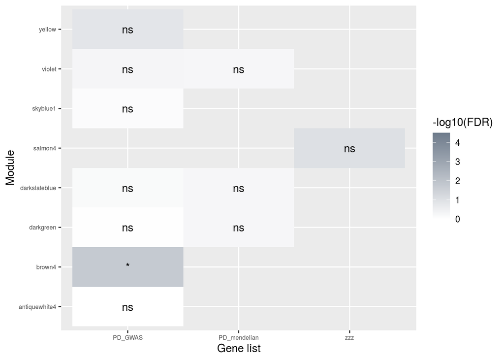

```r
# Filter repeats
N_melt_summ <- N_pvals_list %>%
  dplyr::distinct()
# Prep for figure
names(N_melt_summ)[names(N_melt_summ)=="module"] <- "Module"
N_melt_summ$Module <- as.character(N_melt_summ$Module)
N_melt_summ$Gene_list <- as.character(N_melt_summ$Gene_list)
N_melt_summ <- rbind(N_melt_summ, c("salmon4", 0.1, "zzz")) # Buffer row just to align figure to NSL figure better
N_melt_summ$FDR <- as.numeric(N_melt_summ$FDR)
N_melt_summ$`-log10(FDR)` <- -log10(N_melt_summ$FDR)
N_melt_summ <- dplyr::arrange(N_melt_summ, Module)
# Plot
ggplot(N_melt_summ, aes(Gene_list, Module)) +
  geom_tile(aes(fill = `-log10(FDR)`)) +
  geom_text(aes(label = signif.num(FDR))) +
  scale_fill_gradient(low = "white", high = "lightsteelblue4", limits = c(0,4.5)) +
  labs(y = "Module", x = "Gene list") +
  theme(axis.text = element_text(size = 6))
```

# 4. Astrocyte network

The overall structure of the network was first examined.

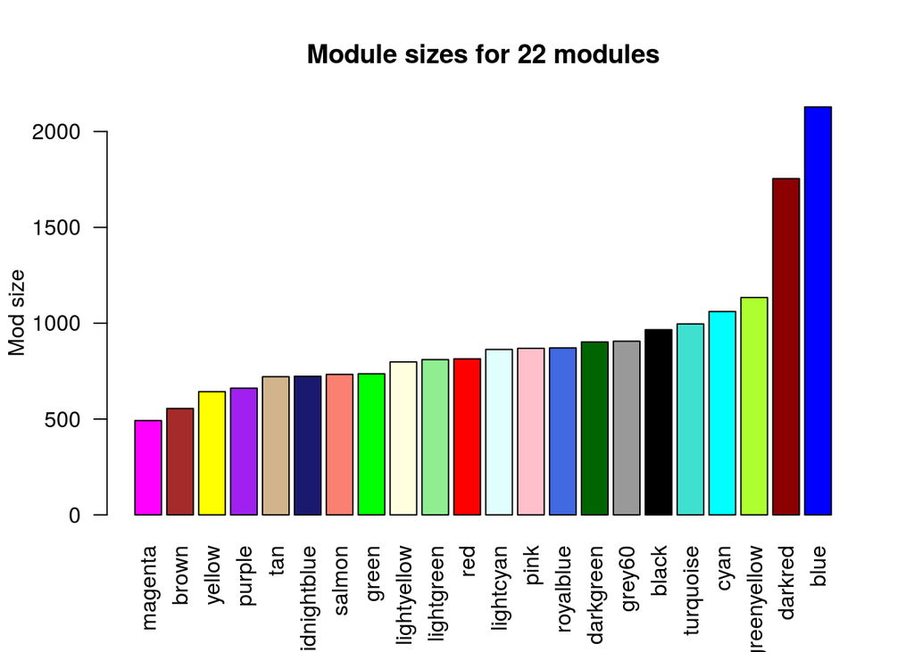

```r
# Load network
MA_net = readRDS(file.path(here::here("data", "Networks", "netFCortex.9.it.50.rds.No.MA.rds")))
# Plot sizes of modules making up the network
CoExpNets::plotModSizes(tissue = MA_net, which.one = "new")
```

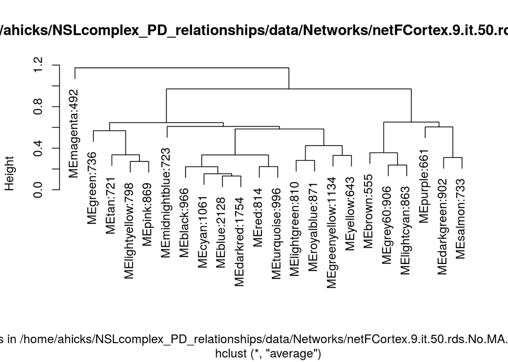

```r
# Obtain eigengenes for each module
MA_net.name <- file.path(here::here("data", "Networks", "netFCortex.9.it.50.rds.No.MA.rds"))
MA_egs <- CoExpNets::getNetworkEigengenes(tissue = MA_net.name, which.one = "new")
# Plot eigengene clustering
CoExpNets::plotEGClustering(tissue = MA_net.name, which.one = "new")
```

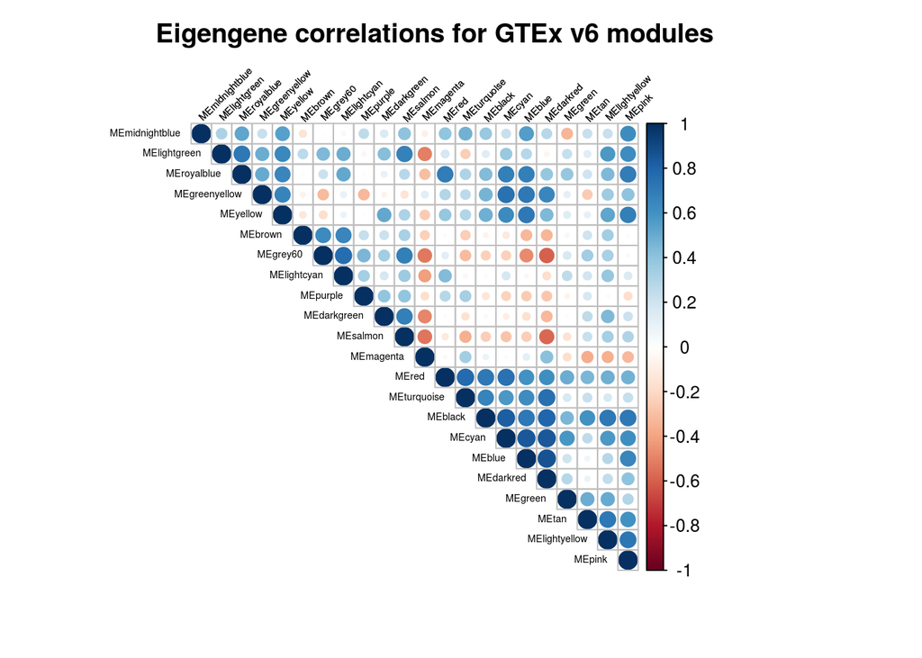

```r
# Plot correlation between modules
corrplot(cor(MA_egs), tl.srt = 45,
         tl.col = "black",
         type = "upper",
         tl.cex = 0.45,
         order = "hclust",
         title = paste0("Eigengene correlations for GTEx v6 modules"),
         mar = c(3, 2, 2.5, 4))
```

## 4.1. Searching gene lists

### NSL genes

```r
# Search genes in network
MA_NSL_mod <- as.data.frame(CoExpNets::reportOnFETGenes(tissue = MA_net.name, genes = NSL_ENSG, which.one = "new", net = NULL))
MA_NSL_mod <- tibble::rownames_to_column(MA_NSL_mod, "ENSG")
MA_NSL_mod <- dplyr::select(MA_NSL_mod, ENSG, module, p.val.mods)
MA_NSL_mod$Gene <- MA_NSL_mod$ENSG
# Add gene symbols
for (i in NSL_list$Ensembl_ID) {
  loc <- match(i, NSL_list$Ensembl_ID)
  MA_NSL_mod$Gene[MA_NSL_mod$Gene== i] <- NSL_list$Gene_symbol[loc]
}
# Get module membership
MA_MM <- as.data.frame(MA_net$MM)
colnames(MA_MM)<- "MM"
MA_MM <- rownames_to_column(MA_MM, "ENSG")
MA_MM$MM <- signif(MA_MM$MM, 4)
# Add MM to table
MA_NSL_mod$MM <- MA_NSL_mod$ENSG
for (i in MA_MM$ENSG) {
  loc <- match(i, MA_MM$ENSG)
  MA_NSL_mod$MM[MA_NSL_mod$MM== i] <- MA_MM$MM[loc]
}
# Reorder table
MA_NSL_mod <- MA_NSL_mod[,c(4,1,5,2,3)]
MA_NSL_mod <- dplyr::arrange(MA_NSL_mod, p.val.mods)
# Store NSL enriched modules
MA_NSL_modules <- unique(MA_NSL_mod$module)
# Print result
MA_NSL_mod
```

| Gene | ENSG | MM | module | p.val.mods |
| --- | --- | --- | --- | --- |
| HCFC1 | ENSG00000172534 | 0.7651 | cyan | 0.009645 |
| KANSL1 | ENSG00000120071 | 0.813 | cyan | 0.009645 |
| WDR5 | ENSG00000196363 | 0.872 | cyan | 0.009645 |
| KANSL3 | ENSG00000114982 | 0.8593 | pink | 0.05475 |
| OGT | ENSG00000147162 | 0.7733 | pink | 0.05475 |
| KAT8 | ENSG00000103510 | 0.7878 | red | 0.3103 |
| KANSL2 | ENSG00000139620 | 0.7803 | royalblue | 0.3284 |
| PHF20 | ENSG00000025293 | 0.8478 | greenyellow | 0.4065 |
| MCRS1 | ENSG00000187778 | 0.8464 | darkred | 0.5597 |

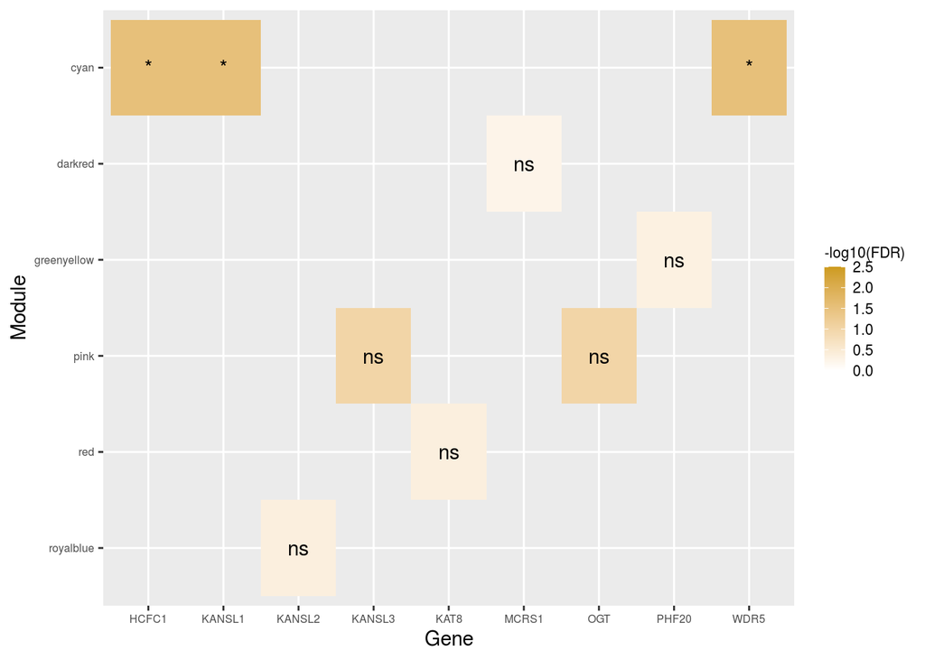

```r
# Format dataframe for figure
MA_NSL_mod$FDR <- p.adjust(MA_NSL_mod$p.val.mods, method = "fdr")
names(MA_NSL_mod)[names(MA_NSL_mod)=="p.val.mods"] <- "p.val"
names(MA_NSL_mod)[names(MA_NSL_mod)=="module"] <- "Module"
MA_NSL_mod$p.val <- as.numeric(MA_NSL_mod$p.val)
MA_NSL_mod <- dplyr::arrange(MA_NSL_mod, Module)
MA_NSL_mod$position <- nrow(MA_NSL_mod):1
MA_NSL_mod$`-log10(p.val)` <- -log10(MA_NSL_mod$p.val)
MA_NSL_mod$`-log10(FDR)` <- -log10(MA_NSL_mod$FDR)
# Produce plot
ggplot(MA_NSL_mod, aes(Gene, reorder(Module, position))) +
  geom_tile(aes(fill = `-log10(FDR)`)) +
  geom_text(aes(label = signif.num(FDR))) +
  scale_fill_gradient(low = "white", high = "goldenrod3", limits = c(0,2.5)) +
  labs(y = "Module", x = "Gene") +
  theme(
    axis.text = element_text(size = 6),
    legend.title = element_text(size = 8),
    legend.text = element_text(size = 8),
    legend.key.size = unit(4, "mm"))
```

The number of genes in the output table was **9**, indicating there were **0** genes missing from the search. These genes appeared in 6 modules, each of which was examined for **enrichment** of cell type specific markers.

```r
# Load cell type markers enriched for each module
MA_mod_enrich <- as.data.frame(getModulesEnrichment(MA_net,
                                                    markers.path = file.path(here::here("data", "GMSCA_source", "markers"))))
# Filter enrichments for NSL modules
MA_mod_enrich_NSL <- dplyr::select(MA_mod_enrich, one_of(MA_NSL_modules))
```

One of the modules containing NSL genes, namely the **darkred** module which contained *MCRS1*, showed **significant enrichment** for **12 types** of **neuronal** cells.

```r
# Only one module contains values <1, examine celltypes more closely
MA_mod_enrich_NSL %>%
  dplyr::filter(darkred <= 0.05) %>%
  dplyr::select(darkred)
```

|  | darkred |
| --- | --- |
| Neuron_CA1_Pyramidal | 5.826550e-11 |
| Neuron_Cortex_Pyramidal_Neuroexpresso | 8.649321e-05 |
| Neuron_Dopaminergic | 8.326832e-03 |
| Neuron_DopaminergicNeuron | 8.326832e-03 |
| Neuron_GABASST_HIPPD_Neuroexpresso | 8.261314e-09 |
| Neuron_Hippocampus_GabaSSTRein_Neuroexpresso | 8.261314e-09 |
| Neuron_Interneuron | 2.064572e-13 |
| Neuron_Interneuton | 2.064572e-13 |
| Neuron_Neuron.Ex1 | 1.663499e-05 |
| Neuron_Neuron.Ex7 | 1.340563e-03 |

[output cut: 2 more lines]

```r
# Compare changes in enrichments
MA_changes <- enrichmentEvolution(gtex_net,
                                  MA_net,
                                  genes = NSL_ENSG,
                                  markers.path = file.path(here::here("data", "GMSCA_source", "markers")))
MA_changes$ENSG <- as.character(MA_changes$gene)
for (i in NSL_list$Ensembl_ID) {
  loc <- match(i, NSL_list$Ensembl_ID)
  MA_changes$gene[MA_changes$gene == i] <- NSL_list$Gene_symbol[loc]
}
```

The cell type enrichments were compared to that of the **primary** coexpression network.

```r
MA_changes[,c(1,2,3,4,5)]
```

| gene | primary.module | primary.enrichment | secondary.module | secondary.enrichment |
| --- | --- | --- | --- | --- |
| HCFC1 | red | - | cyan | - |
| KANSL1 | red | - | cyan | - |
| KANSL2 | greenyellow | - | royalblue | - |
| KANSL3 | magenta | - | pink | - |
| KAT8 | darkred | Neuron_Dopaminergic, Neuron_DopaminergicNeuron | red | - |
| MCRS1 | darkred | Neuron_Dopaminergic, Neuron_DopaminergicNeuron | darkred | Neuron_CA1_Pyramidal, Neuron_Cortex_Pyramidal_Neuroexpresso, Neuron_Dopaminergic, Neuron_DopaminergicNeuron, Neuron_GABASST_HIPPD_Neuroexpresso, Neuron_Hippocampus_GabaSSTRein_Neuroexpresso, Neuron_In… |
| OGT | red | - | pink | - |
| PHF20 | grey60 | - | greenyellow | - |
| WDR5 | red | - | cyan | - |

The results tables for the following gene lists were filtered for the 6 modules containing NSL genes.

### PD mendelian genes

```r
# Search genes in network
MA_PD_mendelian_mod <- as.data.frame(CoExpNets::reportOnFETGenes(tissue = MA_net.name, genes = PD_mendelian_ENSG, which.one = "new", net = NULL))
MA_PD_mendelian_mod <- tibble::rownames_to_column(MA_PD_mendelian_mod, "ENSG")
MA_PD_mendelian_mod <- dplyr::select(MA_PD_mendelian_mod, ENSG, module, p.val.mods)
MA_PD_mendelian_mod$Gene <- MA_PD_mendelian_mod$ENSG
# Add gene symbols
for (i in PD_mendelian_list$Ensembl_ID) {
  loc <- match(i, PD_mendelian_list$Ensembl_ID)
  MA_PD_mendelian_mod$Gene[MA_PD_mendelian_mod$Gene== i] <- PD_mendelian_list$Gene_symbol[loc]
}
# Add MM to table
MA_PD_mendelian_mod$MM <- MA_PD_mendelian_mod$ENSG
for (i in MA_MM$ENSG) {
  loc <- match(i, MA_MM$ENSG)
  MA_PD_mendelian_mod$MM[MA_PD_mendelian_mod$MM== i] <- MA_MM$MM[loc]
}
# Reorder table
MA_PD_mendelian_mod <- MA_PD_mendelian_mod[,c(4,1,5,2,3)]
MA_PD_mendelian_mod <- dplyr::arrange(MA_PD_mendelian_mod, p.val.mods)
# Filter for NSL enriched modules
MA_PD_mendelian_mod1 <- filter(MA_PD_mendelian_mod, module %in% MA_NSL_modules)
# Print result
MA_PD_mendelian_mod1
```

| Gene | ENSG | MM | module | p.val.mods |
| --- | --- | --- | --- | --- |
| ATP13A2 | ENSG00000159363 | 0.9379 | darkred | 0.009023 |
| ATP1A3 | ENSG00000105409 | 0.9524 | darkred | 0.009023 |
| C19orf12 | ENSG00000131943 | 0.8927 | darkred | 0.009023 |
| GBA | ENSG00000177628 | 0.7702 | darkred | 0.009023 |
| HTT | ENSG00000197386 | 0.9069 | darkred | 0.009023 |
| JPH3 | ENSG00000154118 | 0.8032 | darkred | 0.009023 |
| MAPT | ENSG00000186868 | 0.9288 | darkred | 0.009023 |
| OPA3 | ENSG00000125741 | 0.8256 | darkred | 0.009023 |
| TUBB4A | ENSG00000104833 | 0.8231 | darkred | 0.009023 |
| GRN | ENSG00000030582 | 0.7225 | red | 0.5108 |

[output cut: 6 more lines]

The number of genes in the output table was **43**, indicating there were **0** genes missing from the search. These genes appeared in 16 modules.

Secondary GCN modules containing genes found in **primary GCN modules alongside NSL genes** were then examined for **enrichment** of cell type specific markers. The modules containing these filtered PD mendelian genes showed **several significant enrichments** for **different cell types**.

```r
# Compare changes in enrichments
MA_PD_mendelian_changes <- enrichmentEvolution(gtex_net,
                                               MA_net,
                                               genes = PD_mendelian_ENSG_fil,
                                               markers.path = file.path(here::here("data", "GMSCA_source","markers")))
MA_PD_mendelian_changes$ENSG <- as.character(MA_PD_mendelian_changes$gene)
for (i in PD_mendelian_list$Ensembl_ID) {
  loc <- match(i, PD_mendelian_list$Ensembl_ID)
  MA_PD_mendelian_changes$gene[MA_PD_mendelian_changes$gene == i] <- PD_mendelian_list$Gene_symbol[loc]
}
```

The cell type enrichments were compared to that of the **primary** coexpression network.

```r
MA_PD_mendelian_changes[,c(1,2,3,4,5)]
```

| gene | primary.module | primary.enrichment | secondary.module | secondary.enrichment |
| --- | --- | --- | --- | --- |
| ATN1 | red | - | lightyellow | - |
| ATXN2 | red | - | cyan | - |
| PLA2G6 | red | - | black | - |
| TH | red | - | black | - |
| LYST | greenyellow | - | royalblue | - |
| SLC39A14 | greenyellow | - | royalblue | - |
| PARK7 | darkred | Neuron_Dopaminergic, Neuron_DopaminergicNeuron | turquoise | Neuron_Dopaminergic, Neuron_DopaminergicNeuron |
| PINK1 | darkred | Neuron_Dopaminergic, Neuron_DopaminergicNeuron | turquoise | Neuron_Dopaminergic, Neuron_DopaminergicNeuron |
| WDR45 | darkred | Neuron_Dopaminergic, Neuron_DopaminergicNeuron | red | - |
| TBP | magenta | - | pink | - |

### PD sporadic genes

```r
# Search genes in network
MA_PD_GWAS_mod <- as.data.frame(CoExpNets::reportOnFETGenes(tissue = MA_net.name, genes = PD_GWAS_ENSG, which.one = "new", net = NULL))
MA_PD_GWAS_mod <- tibble::rownames_to_column(MA_PD_GWAS_mod, "ENSG")
MA_PD_GWAS_mod <- dplyr::select(MA_PD_GWAS_mod, ENSG, module, p.val.mods)
MA_PD_GWAS_mod$Gene <- MA_PD_GWAS_mod$ENSG
# Add gene symbols
for (i in PD_GWAS_list$Ensembl_ID) {
  loc <- match(i, PD_GWAS_list$Ensembl_ID)
  MA_PD_GWAS_mod$Gene[MA_PD_GWAS_mod$Gene== i] <- PD_GWAS_list$Gene_symbol[loc]
}
# Add MM to table
MA_PD_GWAS_mod$MM <- MA_PD_GWAS_mod$ENSG
for (i in MA_MM$ENSG) {
  loc <- match(i, MA_MM$ENSG)
  MA_PD_GWAS_mod$MM[MA_PD_GWAS_mod$MM== i] <- MA_MM$MM[loc]
}
# Reorder table
MA_PD_GWAS_mod <- MA_PD_GWAS_mod[,c(4,1,5,2,3)]
MA_PD_GWAS_mod <- dplyr::arrange(MA_PD_GWAS_mod, p.val.mods)
# Filter for NSL enriched modules
MA_PD_GWAS_mod1 <- filter(MA_PD_GWAS_mod, module %in% MA_NSL_modules)
# Print result
MA_PD_GWAS_mod1
```

| Gene | ENSG | MM | module | p.val.mods |
| --- | --- | --- | --- | --- |
| BIN3 | ENSG00000147439 | 0.8467 | red | 0.04542 |
| CTSB | ENSG00000164733 | 0.8259 | red | 0.04542 |
| DLST | ENSG00000119689 | 0.7692 | red | 0.04542 |
| FDFT1 | ENSG00000079459 | 0.5529 | red | 0.04542 |
| GRN | ENSG00000030582 | 0.7225 | red | 0.04542 |
| MALSU1 | ENSG00000156928 | 0.8413 | red | 0.04542 |
| SGF29 | ENSG00000176476 | 0.6446 | red | 0.04542 |
| STX4 | ENSG00000103496 | 0.7383 | red | 0.04542 |
| TUFM | ENSG00000178952 | 0.7291 | red | 0.04542 |
| VKORC1 | ENSG00000167397 | 0.471 | red | 0.04542 |

[output cut: 33 more lines]

The number of genes in the output table was **150**, indicating there were **0** genes missing from the search. These genes appeared in 23 modules.

Secondary GCN modules containing genes found in **primary GCN modules alongside NSL genes** were then examined for **enrichment** of cell type specific markers. The modules containing these filtered sporadic PD genes showed **several significant enrichments** for **different cell types**.

```r
# Compare changes in enrichments
MA_PD_GWAS_changes <- enrichmentEvolution(gtex_net, MA_net, genes = PD_GWAS_ENSG_fil, markers.path = file.path(here::here("data", "GMSCA_source","markers")))
MA_PD_GWAS_changes$ENSG <- as.character(MA_PD_GWAS_changes$gene)
for (i in PD_GWAS_list$Ensembl_ID) {
  loc <- match(i, PD_GWAS_list$Ensembl_ID)
  MA_PD_GWAS_changes$gene[MA_PD_GWAS_changes$gene == i] <- PD_GWAS_list$Gene_symbol[loc]
}
```

The cell type enrichments were compared to that of the **primary** coexpression network.

```r
MA_PD_GWAS_changes[,c(1,2,3,4,5)]
```

| gene | primary.module | primary.enrichment | secondary.module | secondary.enrichment |
| --- | --- | --- | --- | --- |
| BIN3 | red | - | red | - |
| CCAR2 | red | - | cyan | - |
| CTSB | red | - | red | - |
| DGKQ | red | - | black | - |
| DLST | red | - | red | - |
| GAK | red | - | black | - |
| GBAP1 | red | - | black | - |
| HSD17B1 | red | - | cyan | - |
| IGSF9B | red | - | cyan | - |
| IP6K2 | red | - | cyan | - |

[output cut: 32 more lines]

## 4.2. Summary

The **frequency** of **genes** within each gene **list** apppearing in each of the **6 NSL enriched modules** was calculated.

```r
# Collate module results into one table
MA1 <- MA_PD_mendelian_mod1['module']
MA1['Gene_list'] <- "PD_mendelian"
MA2 <- MA_PD_GWAS_mod1['module']
MA2['Gene_list'] <- "PD_GWAS"
MA_mods_list <- do.call(rbind, list(MA1, MA2))
# Display as frequency of each module within each list
MA_mod_freq <- with(MA_mods_list, table(module, Gene_list))
MA_mod_freq <- as.data.frame.matrix(MA_mod_freq)
MA_mod_freq <- dplyr::filter(MA_mod_freq, rownames(MA_mod_freq) %in% MA_NSL_modules)
MA_mod_freq <- MA_mod_freq[c(5, 2, 3, 4, 1, 6),]
```

```r
knitr::kable(MA_mod_freq)
```

|  | PD_GWAS | PD_mendelian |
| --- | --- | --- |
| red | 10 | 2 |
| darkred | 12 | 9 |
| greenyellow | 5 | 0 |
| pink | 4 | 1 |
| cyan | 9 | 2 |
| royalblue | 3 | 2 |

The **significance** of the **enrichments** of each **gene list** within each of the **6 NSL enriched modules** was also calculated. P-values were **FDR-corrected** before summarising.

```r
# FDR correct p values
MA_PD_mendelian_mod1$FDR <- p.adjust(MA_PD_mendelian_mod1$p.val.mods, method = "fdr")
MA_PD_GWAS_mod1$FDR <- p.adjust(MA_PD_GWAS_mod1$p.val.mods, method = "fdr")
```

```r
# Collate module results into one table
MAs1 <- data.frame(MA_PD_mendelian_mod1$module, MA_PD_mendelian_mod1$FDR)
names(MAs1)[names(MAs1)=="MA_PD_mendelian_mod1.FDR"] <- "FDR"
names(MAs1)[names(MAs1)=="MA_PD_mendelian_mod1.module"] <- "Module"
MAs1$Gene_list <- "PD_mendelian"
MAs2 <- data.frame(MA_PD_GWAS_mod1$module, MA_PD_GWAS_mod1$FDR)
names(MAs2)[names(MAs2)=="MA_PD_GWAS_mod1.FDR"] <- "FDR"
names(MAs2)[names(MAs2)=="MA_PD_GWAS_mod1.module"] <- "Module"
MAs2$Gene_list <- "PD_GWAS"
MA_pvals_list <- dplyr::bind_rows(MAs1, MAs2)
# Display as true/false table
MA_TF <- MA_pvals_list %>%
  dplyr::distinct() %>%
  tidyr::spread(Gene_list, FDR)
MA_TF <- tibble::column_to_rownames(MA_TF, var = "Module")
MA_TF <- MA_TF[c(5, 2, 3, 4, 1, 6),]
```

```r
knitr::kable(MA_TF)
```

|  | PD_GWAS | PD_mendelian |
| --- | --- | --- |
| red | 0.1953060 | 0.6740923 |
| darkred | 0.6995129 | 0.0160409 |
| greenyellow | 0.9331000 | NA |
| pink | 0.9331000 | 0.8435000 |
| cyan | 0.6223684 | 0.7005867 |
| royalblue | 0.9331000 | 0.6740923 |

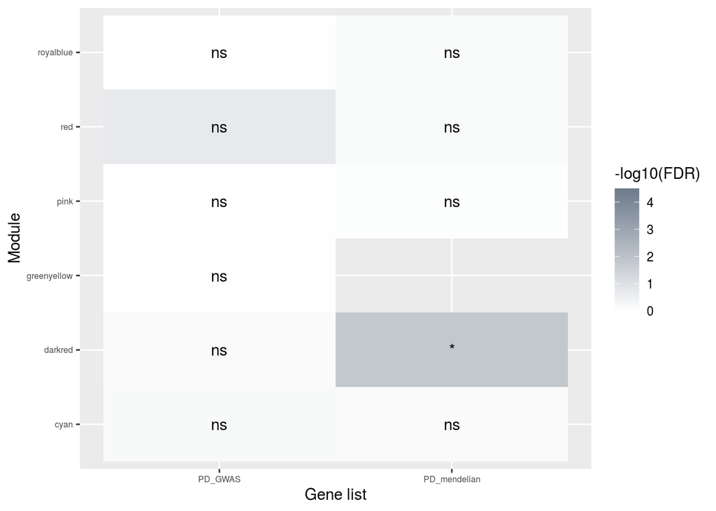

```r
# Filter repeats
MA_melt_summ <- MA_pvals_list %>%
  dplyr::distinct()
# Prep for figure
MA_melt_summ$Module <- as.character(MA_melt_summ$Module)
MA_melt_summ$Gene_list <- as.character(MA_melt_summ$Gene_list)
MA_melt_summ <- dplyr::arrange(MA_melt_summ, Module)
MA_melt_summ$`-log10(FDR)` <- -log10(MA_melt_summ$FDR)
# Plot
ggplot(MA_melt_summ, aes(Gene_list, Module)) +
  geom_tile(aes(fill = `-log10(FDR)`)) +
  geom_text(aes(label = signif.num(FDR))) +
  scale_fill_gradient(low = "white", high = "lightsteelblue4", limits = c(0,4.5)) +
  labs(y = "Module", x = "Gene list") +
  theme(axis.text = element_text(size = 6))
```

# 5. Microglia network

The overall structure of the network was first examined.

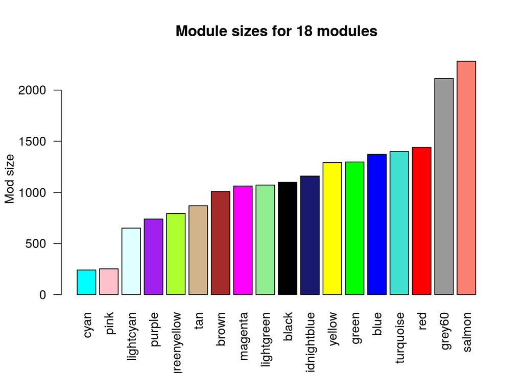

```r
# Load network
MG_net = readRDS(file.path(here::here("data", "Networks", "netFCortex.9.it.50.rds.No.MG.rds")))
# Plot sizes of modules making up the network
CoExpNets::plotModSizes(tissue = MG_net, which.one = "new")
```

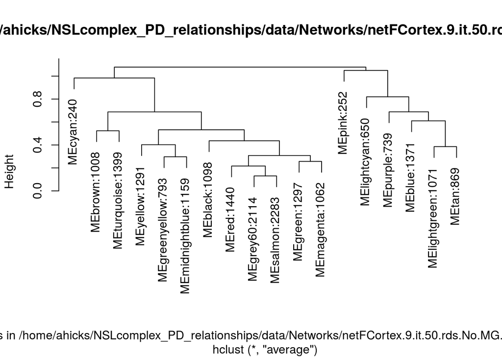

```r
# Obtain eigengenes for each module
MG_net.name <- file.path(here::here("data", "Networks", "netFCortex.9.it.50.rds.No.MG.rds"))
MG_egs <- CoExpNets::getNetworkEigengenes(tissue = MG_net.name, which.one = "new")
# Plot eigengene clustering
CoExpNets::plotEGClustering(tissue = MG_net.name, which.one = "new")
```

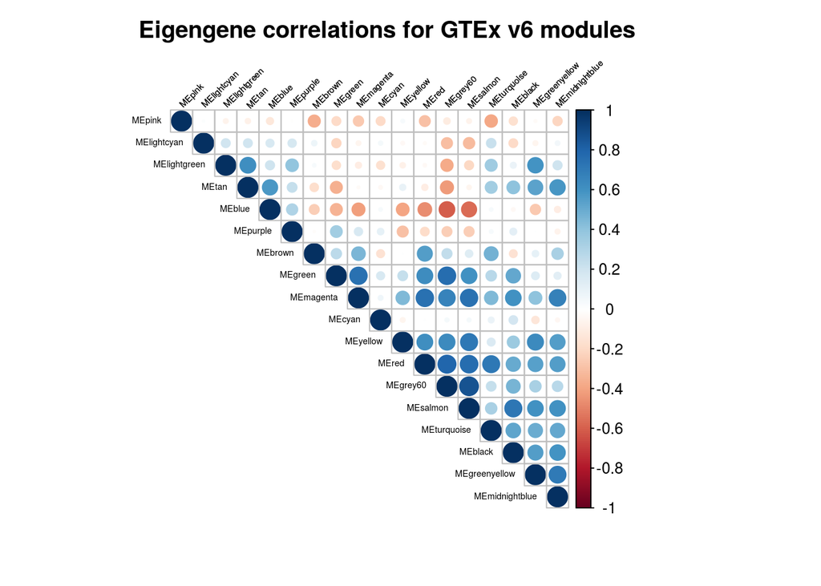

```r
# Plot correlation between modules
corrplot(cor(MG_egs), tl.srt = 45,
         tl.col = "black",
         type = "upper",
         tl.cex = 0.45,
         order = "hclust",
         title = paste0("Eigengene correlations for GTEx v6 modules"),
         mar = c(3, 2, 2.5, 4))
```

## 5.1. Searching gene lists

### NSL genes

```r
# Search genes in network
MG_NSL_mod <- as.data.frame(CoExpNets::reportOnFETGenes(tissue = MG_net.name, genes = NSL_ENSG, which.one = "new", net = NULL))
MG_NSL_mod <- tibble::rownames_to_column(MG_NSL_mod, "ENSG")
MG_NSL_mod <- dplyr::select(MG_NSL_mod, ENSG, module, p.val.mods)
MG_NSL_mod$Gene <- MG_NSL_mod$ENSG
# Add gene symbols
for (i in NSL_list$Ensembl_ID) {
  loc <- match(i, NSL_list$Ensembl_ID)
  MG_NSL_mod$Gene[MG_NSL_mod$Gene== i] <- NSL_list$Gene_symbol[loc]
}
# Get module membership
MG_MM <- as.data.frame(MG_net$MM)
colnames(MG_MM)<- "MM"
MG_MM <- rownames_to_column(MG_MM, "ENSG")
MG_MM$MM <- signif(MG_MM$MM, 4)
# Add MM to table
MG_NSL_mod$MM <- MG_NSL_mod$ENSG
for (i in MG_MM$ENSG) {
  loc <- match(i, MG_MM$ENSG)
  MG_NSL_mod$MM[MG_NSL_mod$MM== i] <- MG_MM$MM[loc]
}
# Reorder table
MG_NSL_mod <- MG_NSL_mod[,c(4,1,5,2,3)]
MG_NSL_mod <- dplyr::arrange(MG_NSL_mod, p.val.mods)
# Store NSL enriched modules
MG_NSL_modules <- unique(MG_NSL_mod$module)
# Print result
MG_NSL_mod
```

| Gene | ENSG | MM | module | p.val.mods |
| --- | --- | --- | --- | --- |
| HCFC1 | ENSG00000172534 | 0.7756 | red | 0.002451 |
| KANSL1 | ENSG00000120071 | 0.8148 | red | 0.002451 |
| OGT | ENSG00000147162 | 0.8116 | red | 0.002451 |
| WDR5 | ENSG00000196363 | 0.8819 | red | 0.002451 |
| KAT8 | ENSG00000103510 | 0.7229 | magenta | 0.386 |
| KANSL2 | ENSG00000139620 | 0.7623 | midnightblue | 0.4135 |
| MCRS1 | ENSG00000187778 | 0.8452 | green | 0.4508 |
| KANSL3 | ENSG00000114982 | 0.8094 | turquoise | 0.477 |
| PHF20 | ENSG00000025293 | 0.8544 | salmon | 0.6615 |

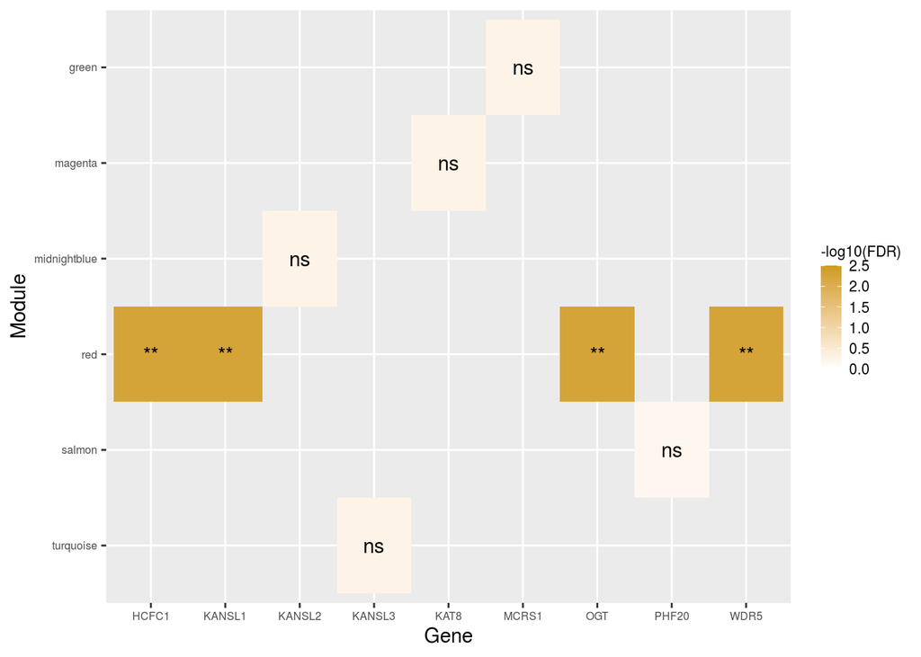

```r
# Format dataframe for figure
MG_NSL_mod$FDR <- p.adjust(MG_NSL_mod$p.val.mods, method = "fdr")
names(MG_NSL_mod)[names(MG_NSL_mod)=="p.val.mods"] <- "p.val"
names(MG_NSL_mod)[names(MG_NSL_mod)=="module"] <- "Module"
MG_NSL_mod$p.val <- as.numeric(MG_NSL_mod$p.val)
MG_NSL_mod <- dplyr::arrange(MG_NSL_mod, Module)
MG_NSL_mod$position <- nrow(MG_NSL_mod):1
MG_NSL_mod$`-log10(p.val)` <- -log10(MG_NSL_mod$p.val)
MG_NSL_mod$`-log10(FDR)` <- -log10(MG_NSL_mod$FDR)
# Produce plot
ggplot(MG_NSL_mod, aes(Gene, reorder(Module, position))) +
  geom_tile(aes(fill = `-log10(FDR)`)) +
  geom_text(aes(label = signif.num(FDR))) +
  scale_fill_gradient(low = "white", high = "goldenrod3", limits = c(0,2.5)) +
  labs(y = "Module", x = "Gene") +
  theme(
    axis.text = element_text(size = 6),
    legend.title = element_text(size = 8),
    legend.text = element_text(size = 8),
    legend.key.size = unit(4, "mm"))
```

The number of genes in the output table was **9**, indicating there were **0** genes missing from the search. These genes appeared in 6 modules, each of which was examined for **enrichment** of cell type specific markers.

```r
# Load cell type markers enriched for each module
MG_mod_enrich <- as.data.frame(getModulesEnrichment(MG_net,
                                                    markers.path = file.path(here::here("data", "GMSCA_source", "markers"))))
# Filter enrichments for NSL modules
MG_mod_enrich_NSL <- dplyr::select(MG_mod_enrich, one_of(MG_NSL_modules))
```

Two of the modules containing NSL genes showed **significant enrichment** for **neuronal** cells:

- **green** contained *MCRS1* and showed enrichment for **dopaminergic neurons** alone

```r
# Examine celltypes more closely
MG_mod_enrich_NSL %>%
  dplyr::filter(green <= 0.05) %>%
  dplyr::select(green)
```

|  | green |
| --- | --- |
| Neuron_Dopaminergic | 6.654353e-06 |
| Neuron_DopaminergicNeuron | 6.654353e-06 |

- **salmon** contained *PHF20* and showed enrichment for **11** types of neurons

```r
# Examine celltypes more closely
MG_mod_enrich_NSL %>%
  dplyr::filter(salmon <= 0.05) %>%
  dplyr::select(salmon)
```

|  | salmon |
| --- | --- |
| Neuron_CA1_Pyramidal | 2.882247e-05 |
| Neuron_D_NEuronCom4 | 3.270871e-06 |
| Neuron_DARMANIS_NEUROND | 5.622914e-04 |
| Neuron_Dopaminergic_Neuron_SN | 1.822348e-04 |
| Neuron_Dopaminergic_SNigra | 1.822348e-04 |
| Neuron_Interneuron | 3.989490e-11 |
| Neuron_Interneuton | 3.989490e-11 |
| Neuron_Pyramidal_CA1 | 2.882247e-05 |
| Neuron_Pyramidal_S1 | 2.022575e-03 |
| Neuron_SN_Dopaminergic | 1.822348e-04 |

[output cut: 1 more lines]

```r
# Compare changes in enrichments
MG_changes <- enrichmentEvolution(gtex_net,
                                  MG_net,
                                  genes = NSL_ENSG,
                                  markers.path = file.path(here::here("data", "GMSCA_source", "markers")))
MG_changes$ENSG <- as.character(MG_changes$gene)
for (i in NSL_list$Ensembl_ID) {
  loc <- match(i, NSL_list$Ensembl_ID)
  MG_changes$gene[MG_changes$gene == i] <- NSL_list$Gene_symbol[loc]
}
```

The cell type enrichments were compared to that of the **primary** coexpression network.

```r
MG_changes[,c(1,2,3,4,5)]
```

| gene | primary.module | primary.enrichment | secondary.module | secondary.enrichment |
| --- | --- | --- | --- | --- |
| HCFC1 | red | - | red | - |
| KANSL1 | red | - | red | - |
| KANSL2 | greenyellow | - | midnightblue | - |
| KANSL3 | magenta | - | turquoise | - |
| KAT8 | darkred | Neuron_Dopaminergic, Neuron_DopaminergicNeuron | magenta | - |
| MCRS1 | darkred | Neuron_Dopaminergic, Neuron_DopaminergicNeuron | green | Neuron_Dopaminergic, Neuron_DopaminergicNeuron |
| OGT | red | - | red | - |
| PHF20 | grey60 | - | salmon | Neuron_CA1_Pyramidal, Neuron_D_NEuronCom4, Neuron_DARMANIS_NEUROND, Neuron_Dopaminergic_Neuron_SN, Neuron_Dopaminergic_SNigra, Neuron_Interneuron, Neuron_Interneuton, Neuron_Pyramidal_CA1, Neuron_Pyra… |
| WDR5 | red | - | red | - |

The results tables for the following gene lists were filtered for the 6 modules containing NSL genes.

### PD mendelian genes

```r
# Search genes in network
MG_PD_mendelian_mod <- as.data.frame(CoExpNets::reportOnFETGenes(tissue = MG_net.name, genes = PD_mendelian_ENSG, which.one = "new", net = NULL))
MG_PD_mendelian_mod <- tibble::rownames_to_column(MG_PD_mendelian_mod, "ENSG")
MG_PD_mendelian_mod <- dplyr::select(MG_PD_mendelian_mod, ENSG, module, p.val.mods)
MG_PD_mendelian_mod$Gene <- MG_PD_mendelian_mod$ENSG
# Add gene symbols
for (i in PD_mendelian_list$Ensembl_ID) {
  loc <- match(i, PD_mendelian_list$Ensembl_ID)
  MG_PD_mendelian_mod$Gene[MG_PD_mendelian_mod$Gene== i] <- PD_mendelian_list$Gene_symbol[loc]
}
# Add MM to table
MG_PD_mendelian_mod$MM <- MG_PD_mendelian_mod$ENSG
for (i in MG_MM$ENSG) {
  loc <- match(i, MG_MM$ENSG)
  MG_PD_mendelian_mod$MM[MG_PD_mendelian_mod$MM== i] <- MG_MM$MM[loc]
}
# Reorder table
MG_PD_mendelian_mod <- MG_PD_mendelian_mod[,c(4,1,5,2,3)]
MG_PD_mendelian_mod <- dplyr::arrange(MG_PD_mendelian_mod, p.val.mods)
# Filter for NSL enriched modules
MG_PD_mendelian_mod1 <- filter(MG_PD_mendelian_mod, module %in% MG_NSL_modules)
# Print result
MG_PD_mendelian_mod1
```

| Gene | ENSG | MM | module | p.val.mods |
| --- | --- | --- | --- | --- |
| ATXN1 | ENSG00000124788 | 0.783 | salmon | 0.0001347 |
| ATXN3 | ENSG00000066427 | 0.8619 | salmon | 0.0001347 |
| C9orf72 | ENSG00000147894 | 0.8223 | salmon | 0.0001347 |
| DCTN1 | ENSG00000204843 | 0.8459 | salmon | 0.0001347 |
| DNAJC6 | ENSG00000116675 | 0.9466 | salmon | 0.0001347 |
| LRRK2 | ENSG00000188906 | 0.6125 | salmon | 0.0001347 |
| PANK2 | ENSG00000125779 | 0.9017 | salmon | 0.0001347 |
| PPP2R2B | ENSG00000156475 | 0.8893 | salmon | 0.0001347 |
| PRKN | ENSG00000185345 | 0.8972 | salmon | 0.0001347 |
| RAB39B | ENSG00000155961 | 0.9359 | salmon | 0.0001347 |

[output cut: 16 more lines]

The number of genes in the output table was **43**, indicating there were **0** genes missing from the search. These genes appeared in 14 modules.

Secondary GCN modules containing genes found in **primary GCN modules alongside NSL genes** were then examined for **enrichment** of cell type specific markers. The modules containing these filtered PD mendelian genes showed **several significant enrichments** for **different cell types**.

```r
# Compare changes in enrichments
MG_PD_mendelian_changes <- enrichmentEvolution(gtex_net,
                                               MG_net,
                                               genes = PD_mendelian_ENSG_fil,
                                               markers.path = file.path(here::here("data", "GMSCA_source","markers")))
MG_PD_mendelian_changes$ENSG <- as.character(MG_PD_mendelian_changes$gene)
for (i in PD_mendelian_list$Ensembl_ID) {
  loc <- match(i, PD_mendelian_list$Ensembl_ID)
  MG_PD_mendelian_changes$gene[MG_PD_mendelian_changes$gene == i] <- PD_mendelian_list$Gene_symbol[loc]
}
```

The cell type enrichments were compared to that of the **primary** coexpression network.

```r
MG_PD_mendelian_changes[,c(1,2,3,4,5)]
```

| gene | primary.module | primary.enrichment | secondary.module | secondary.enrichment |
| --- | --- | --- | --- | --- |
| ATN1 | red | - | red | - |
| ATXN2 | red | - | red | - |
| PLA2G6 | red | - | red | - |
| TH | red | - | red | - |
| LYST | greenyellow | - | midnightblue | - |
| SLC39A14 | greenyellow | - | midnightblue | - |
| PARK7 | darkred | Neuron_Dopaminergic, Neuron_DopaminergicNeuron | green | Neuron_Dopaminergic, Neuron_DopaminergicNeuron |
| PINK1 | darkred | Neuron_Dopaminergic, Neuron_DopaminergicNeuron | green | Neuron_Dopaminergic, Neuron_DopaminergicNeuron |
| WDR45 | darkred | Neuron_Dopaminergic, Neuron_DopaminergicNeuron | green | Neuron_Dopaminergic, Neuron_DopaminergicNeuron |
| TBP | magenta | - | magenta | - |

### PD sporadic genes

```r
# Search genes in network
MG_PD_GWAS_mod <- as.data.frame(CoExpNets::reportOnFETGenes(tissue = MG_net.name, genes = PD_GWAS_ENSG, which.one = "new", net = NULL))
MG_PD_GWAS_mod <- tibble::rownames_to_column(MG_PD_GWAS_mod, "ENSG")
MG_PD_GWAS_mod <- dplyr::select(MG_PD_GWAS_mod, ENSG, module, p.val.mods)
MG_PD_GWAS_mod$Gene <- MG_PD_GWAS_mod$ENSG
# Add gene symbols
for (i in PD_GWAS_list$Ensembl_ID) {
  loc <- match(i, PD_GWAS_list$Ensembl_ID)
  MG_PD_GWAS_mod$Gene[MG_PD_GWAS_mod$Gene== i] <- PD_GWAS_list$Gene_symbol[loc]
}
# Add MM to table
MG_PD_GWAS_mod$MM <- MG_PD_GWAS_mod$ENSG
for (i in MG_MM$ENSG) {
  loc <- match(i, MG_MM$ENSG)
  MG_PD_GWAS_mod$MM[MG_PD_GWAS_mod$MM== i] <- MG_MM$MM[loc]
}
# Reorder table
MG_PD_GWAS_mod <- MG_PD_GWAS_mod[,c(4,1,5,2,3)]
MG_PD_GWAS_mod <- dplyr::arrange(MG_PD_GWAS_mod, p.val.mods)
# Filter for NSL enriched modules
MG_PD_GWAS_mod1 <- filter(MG_PD_GWAS_mod, module %in% MG_NSL_modules)
# Print result
MG_PD_GWAS_mod1
```

| Gene | ENSG | MM | module | p.val.mods |
| --- | --- | --- | --- | --- |
| CCAR2 | ENSG00000158941 | 0.876 | red | 0.02986 |
| DGKQ | ENSG00000145214 | 0.8728 | red | 0.02986 |
| GAK | ENSG00000178950 | 0.8691 | red | 0.02986 |
| GBAP1 | ENSG00000160766 | 0.8177 | red | 0.02986 |
| HSD17B1 | ENSG00000108786 | 0.659 | red | 0.02986 |
| IGSF9B | ENSG00000080854 | 0.5677 | red | 0.02986 |
| IP6K2 | ENSG00000068745 | 0.7652 | red | 0.02986 |
| PGS1 | ENSG00000087157 | 0.8033 | red | 0.02986 |
| POLR2A | ENSG00000181222 | 0.7897 | red | 0.02986 |
| PRSS53 | ENSG00000151006 | 0.5862 | red | 0.02986 |

[output cut: 51 more lines]

The number of genes in the output table was **150**, indicating there were **0** genes missing from the search. These genes appeared in 19 modules.

Secondary GCN modules containing genes found in **primary GCN modules alongside NSL genes** were then examined for **enrichment** of cell type specific markers. The modules containing these filtered sporadic PD genes showed **several significant enrichments** for **different cell types**.

```r
# Compare changes in enrichments
MG_PD_GWAS_changes <- enrichmentEvolution(gtex_net,
                                          MG_net,
                                          genes = PD_GWAS_ENSG_fil,
                                          markers.path = file.path(here::here("data", "GMSCA_source","markers")))
MG_PD_GWAS_changes$ENSG <- as.character(MG_PD_GWAS_changes$gene)
for (i in PD_GWAS_list$Ensembl_ID) {
  loc <- match(i, PD_GWAS_list$Ensembl_ID)
  MG_PD_GWAS_changes$gene[MG_PD_GWAS_changes$gene == i] <- PD_GWAS_list$Gene_symbol[loc]
}
```

The cell type enrichments were compared to that of the **primary** coexpression network.

```r
MG_PD_GWAS_changes[,c(1,2,3,4,5)]
```

| gene | primary.module | primary.enrichment | secondary.module | secondary.enrichment |
| --- | --- | --- | --- | --- |
| BIN3 | red | - | magenta | - |
| CCAR2 | red | - | red | - |
| CTSB | red | - | magenta | - |
| DGKQ | red | - | red | - |
| DLST | red | - | magenta | - |
| GAK | red | - | red | - |
| GBAP1 | red | - | red | - |
| HSD17B1 | red | - | red | - |
| IGSF9B | red | - | red | - |
| IP6K2 | red | - | red | - |

[output cut: 32 more lines]

## 5.2. Summary

The **frequency** of **genes** within each gene **list** apppearing in each of the **6 NSL enriched modules** was calculated.

```r
# Collate module results into one table
MG1 <- MG_PD_mendelian_mod1['module']
MG1['Gene_list'] <- "PD_mendelian"
MG2 <- MG_PD_GWAS_mod1['module']
MG2['Gene_list'] <- "PD_GWAS"
MG_mods_list <- do.call(rbind, list(MG1, MG2))
# Display as frequency of each module within each list
MG_mod_freq <- with(MG_mods_list, table(module, Gene_list))
MG_mod_freq <- as.data.frame.matrix(MG_mod_freq)
MG_mod_freq <- dplyr::filter(MG_mod_freq, rownames(MG_mod_freq) %in% MG_NSL_modules)
MG_mod_freq <- MG_mod_freq[c(5, 2, 3, 4, 1, 6), ]
```

```r
knitr::kable(MG_mod_freq)
```

|  | PD_GWAS | PD_mendelian |
| --- | --- | --- |
| salmon | 17 | 14 |
| magenta | 9 | 1 |
| midnightblue | 3 | 3 |
| red | 16 | 4 |
| green | 8 | 4 |
| turquoise | 8 | 0 |

The **significance** of the **enrichments** of each **gene list** within each of the **6 NSL enriched modules** was also calculated. P-values were **FDR-corrected** before summarising.

```r
# FDR correct p values
MG_PD_mendelian_mod1$FDR <- p.adjust(MG_PD_mendelian_mod1$p.val.mods, method = "fdr")
MG_PD_GWAS_mod1$FDR <- p.adjust(MG_PD_GWAS_mod1$p.val.mods, method = "fdr")
```

```r
# Collate module results into one table
MGs1 <- data.frame(MG_PD_mendelian_mod1$module, MG_PD_mendelian_mod1$FDR)
names(MGs1)[names(MGs1)=="MG_PD_mendelian_mod1.FDR"] <- "FDR"
names(MGs1)[names(MGs1)=="MG_PD_mendelian_mod1.module"] <- "Module"
MGs1$Gene_list <- "PD_mendelian"
MGs2 <- data.frame(MG_PD_GWAS_mod1$module, MG_PD_GWAS_mod1$FDR)
names(MGs2)[names(MGs2)=="MG_PD_GWAS_mod1.FDR"] <- "FDR"
names(MGs2)[names(MGs2)=="MG_PD_GWAS_mod1.module"] <- "Module"
MGs2$Gene_list <- "PD_GWAS"
MG_pvals_list <- dplyr::bind_rows(MGs1, MGs2)
# Display as true/false table
MG_TF <- MG_pvals_list %>%
  dplyr::distinct() %>%
  tidyr::spread(Gene_list, FDR)
MG_TF <- tibble::column_to_rownames(MG_TF, var = "Module")
MG_TF <- MG_TF[c(6, 2, 3, 1, 5, 4), ]
```

```r
knitr::kable(MG_TF)
```

|  | PD_GWAS | PD_mendelian |
| --- | --- | --- |
| turquoise | 0.7582931 | NA |
| magenta | 0.5071714 | 0.8975000 |
| midnightblue | 0.9852000 | 0.4557280 |
| green | 0.7582931 | 0.4112333 |
| salmon | 0.5071714 | 0.0002502 |
| red | 0.1138412 | 0.4177727 |

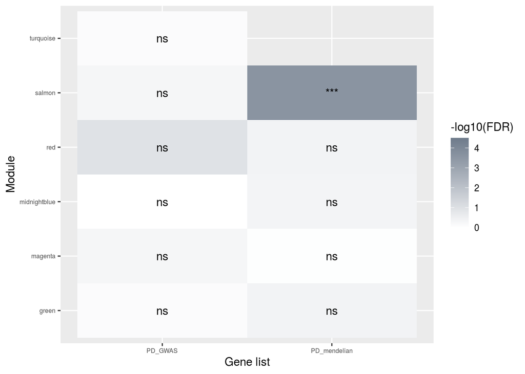

```r
# Filter repeats
MG_melt_summ <- MG_pvals_list %>%
  dplyr::distinct()
# Prep for figure
MG_melt_summ$Module <- as.character(MG_melt_summ$Module)
MG_melt_summ$Gene_list <- as.character(MG_melt_summ$Gene_list)
MG_melt_summ <- dplyr::arrange(MG_melt_summ, Module)
MG_melt_summ$`-log10(FDR)` <- -log10(MG_melt_summ$FDR)
# Plot
ggplot(MG_melt_summ, aes(Gene_list, Module)) +
  geom_tile(aes(fill = `-log10(FDR)`)) +
  geom_text(aes(label = signif.num(FDR))) +
  scale_fill_gradient(low = "white", high = "lightsteelblue4", limits = c(0,4.5)) +
  labs(y = "Module", x = "Gene list") +
  theme(axis.text = element_text(size = 6))
```

# 6. Oligodendrocyte network

The overall structure of the network was first examined.

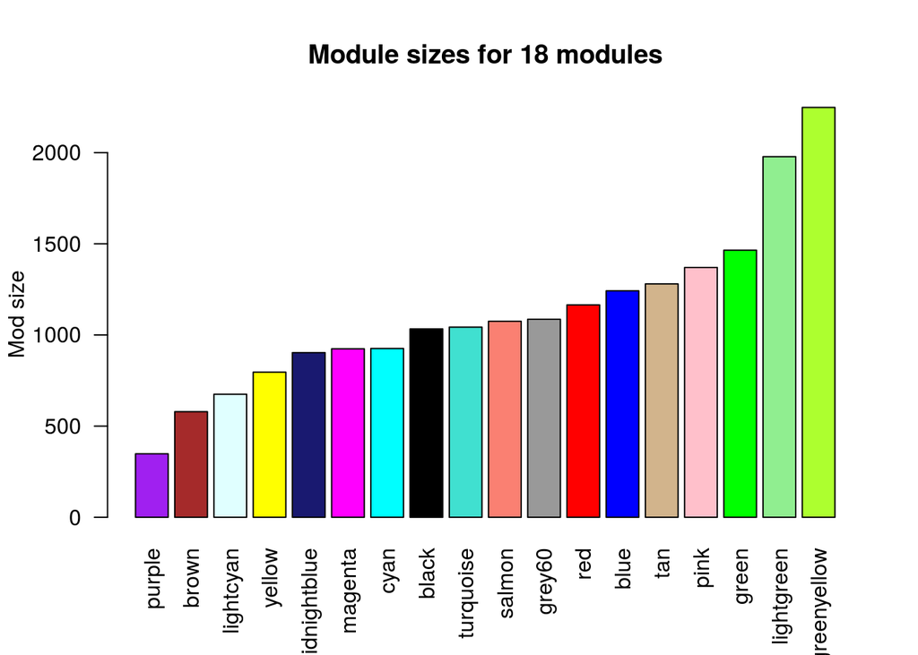

```r
# Load network
OLG_net = readRDS(file.path(here::here("data", "Networks", "netFCortex.9.it.50.rds.No.OLG.rds")))
# Plot sizes of modules making up the network
CoExpNets::plotModSizes(tissue = OLG_net, which.one = "new")
```

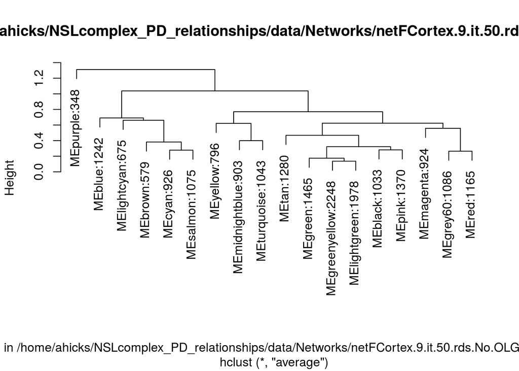

```r
# Obtain eigengenes for each module
OLG_net.name <- file.path(here::here("data", "Networks", "netFCortex.9.it.50.rds.No.OLG.rds"))
OLG_egs <- CoExpNets::getNetworkEigengenes(tissue = OLG_net.name, which.one = "new")
# Plot eigengene clustering
CoExpNets::plotEGClustering(tissue = OLG_net.name, which.one = "new")
```

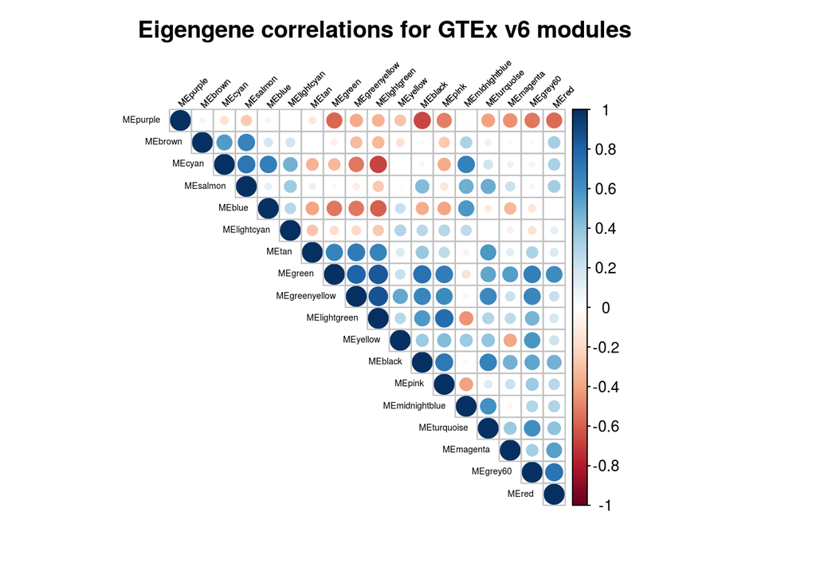

```r
# Plot correlation between modules
corrplot(cor(OLG_egs), tl.srt = 45,
         tl.col = "black",
         type = "upper",
         tl.cex = 0.45,
         order = "hclust",
         title = paste0("Eigengene correlations for GTEx v6 modules"),
         mar = c(3, 2, 2.5, 4))
```

## 6.1. Searching gene lists

### NSL genes

```r
# Search genes in network
OLG_NSL_mod <- as.data.frame(CoExpNets::reportOnFETGenes(tissue = OLG_net.name,
                                                         genes = NSL_ENSG,
                                                         which.one = "new",
                                                         net = NULL))
OLG_NSL_mod <- tibble::rownames_to_column(OLG_NSL_mod, "ENSG")
OLG_NSL_mod <- dplyr::select(OLG_NSL_mod, ENSG, module, p.val.mods)
OLG_NSL_mod$Gene <- OLG_NSL_mod$ENSG
# Add gene symbols
for (i in NSL_list$Ensembl_ID) {
  loc <- match(i, NSL_list$Ensembl_ID)
  OLG_NSL_mod$Gene[OLG_NSL_mod$Gene== i] <- NSL_list$Gene_symbol[loc]
}
# Get module membership
OLG_MM <- as.data.frame(OLG_net$MM)
colnames(OLG_MM)<- "MM"
OLG_MM <- rownames_to_column(OLG_MM, "ENSG")
OLG_MM$MM <- signif(OLG_MM$MM, 4)
# Add MM to table
OLG_NSL_mod$MM <- OLG_NSL_mod$ENSG
for (i in OLG_MM$ENSG) {
  loc <- match(i, OLG_MM$ENSG)
  OLG_NSL_mod$MM[OLG_NSL_mod$MM== i] <- OLG_MM$MM[loc]
}
# Reorder table
OLG_NSL_mod <- OLG_NSL_mod[,c(4,1,5,2,3)]
OLG_NSL_mod <- dplyr::arrange(OLG_NSL_mod, p.val.mods)
# Store NSL enriched modules
OLG_NSL_modules <- unique(OLG_NSL_mod$module)
# Print result
OLG_NSL_mod
```

| Gene | ENSG | MM | module | p.val.mods |
| --- | --- | --- | --- | --- |
| HCFC1 | ENSG00000172534 | 0.7813 | green | 0.002612 |
| KANSL1 | ENSG00000120071 | 0.797 | green | 0.002612 |
| OGT | ENSG00000147162 | 0.768 | green | 0.002612 |
| WDR5 | ENSG00000196363 | 0.8969 | green | 0.002612 |
| KAT8 | ENSG00000103510 | 0.7449 | black | 0.3775 |
| KANSL2 | ENSG00000139620 | 0.7667 | turquoise | 0.3805 |
| KANSL3 | ENSG00000114982 | 0.8572 | grey60 | 0.3929 |
| MCRS1 | ENSG00000187778 | 0.8529 | pink | 0.4697 |
| PHF20 | ENSG00000025293 | 0.8539 | greenyellow | 0.6555 |

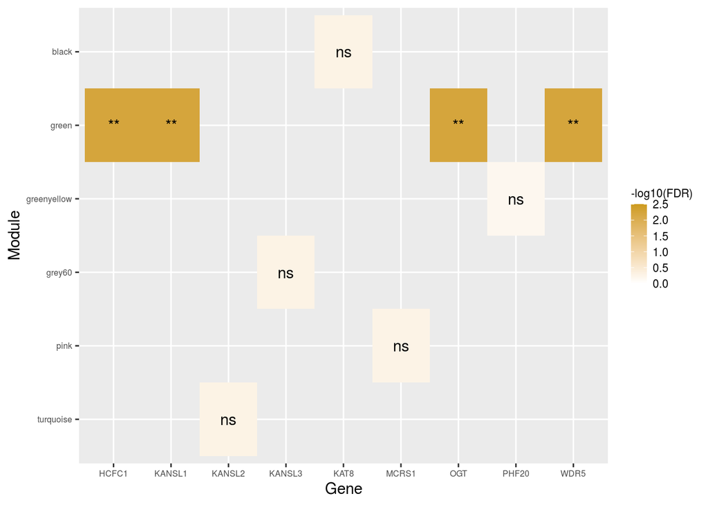

```r
# Format dataframe for figure
OLG_NSL_mod$FDR <- p.adjust(OLG_NSL_mod$p.val.mods, method = "fdr")
names(OLG_NSL_mod)[names(OLG_NSL_mod)=="p.val.mods"] <- "p.val"
names(OLG_NSL_mod)[names(OLG_NSL_mod)=="module"] <- "Module"
OLG_NSL_mod$p.val <- as.numeric(OLG_NSL_mod$p.val)
OLG_NSL_mod <- dplyr::arrange(OLG_NSL_mod, Module)
OLG_NSL_mod$position <- nrow(OLG_NSL_mod):1
OLG_NSL_mod$`-log10(p.val)` <- -log10(OLG_NSL_mod$p.val)
OLG_NSL_mod$`-log10(FDR)` <- -log10(OLG_NSL_mod$FDR)
# Produce plot
ggplot(OLG_NSL_mod, aes(Gene, reorder(Module, position))) +
  geom_tile(aes(fill = `-log10(FDR)`)) +
  geom_text(aes(label = signif.num(FDR))) +
  scale_fill_gradient(low = "white", high = "goldenrod3", limits = c(0,2.5)) +
  labs(y = "Module", x = "Gene") +
  theme(
    axis.text = element_text(size = 6),
    legend.title = element_text(size = 8),
    legend.text = element_text(size = 8),
    legend.key.size = unit(4, "mm"))
```

The number of genes in the output table was **9**, indicating there were **0** genes missing from the search. These genes appeared in 6 modules, each of which was examined for **enrichment** of cell type specific markers.

```r
# Load cell type markers enriched for each module
OLG_mod_enrich <- as.data.frame(getModulesEnrichment(OLG_net,
                                                     markers.path = file.path(here::here("data", "GMSCA_source", "markers"))))
# Filter enrichments for NSL modules
OLG_mod_enrich_NSL <- dplyr::select(OLG_mod_enrich, one_of(OLG_NSL_modules))
```

Two of the modules containing NSL genes showed **significant enrichment** for **neuronal** cells:

- **pink** contained *MCRS1* and showed enrichment for **dopaminergic neurons** as well as **cortical oligodendrocytes**

```r
# Examine celltypes more closely
OLG_mod_enrich_NSL %>%
  dplyr::filter(pink <= 0.05) %>%
  dplyr::select(pink)
```

|  | pink |
| --- | --- |
| Neuron_Dopaminergic | 1.610652e-05 |
| Neuron_DopaminergicNeuron | 1.610652e-05 |
| Oligodendrocyte_Cortex_Oligo_Neuroexpresso | 7.417512e-03 |

- **greenyellow** contained *PHF20* and showed enrichment for **8** types of neurons

```r
# Examine celltypes more closely
OLG_mod_enrich_NSL %>%
  dplyr::filter(greenyellow <= 0.05) %>%
  dplyr::select(greenyellow)
```

|  | greenyellow |
| --- | --- |
| Neuron_D_NEuronCom4 | 3.497194e-05 |
| Neuron_DARMANIS_NEUROND | 5.108473e-03 |
| Neuron_Dopaminergic_Neuron_SN | 8.344252e-05 |
| Neuron_Dopaminergic_SNigra | 8.344252e-05 |
| Neuron_Interneuron | 2.313604e-09 |
| Neuron_Interneuton | 2.313604e-09 |
| Neuron_SN_Dopaminergic | 8.344252e-05 |
| Neuron_SN_DopaminergicNeuron | 8.344252e-05 |

```r
# Compare changes in enrichments
OLG_changes <- enrichmentEvolution(gtex_net,
                                   OLG_net,
                                   genes = NSL_ENSG,
                                   markers.path = file.path(here::here("data", "GMSCA_source", "markers")))
OLG_changes$ENSG <- as.character(OLG_changes$gene)
for (i in NSL_list$Ensembl_ID) {
  loc <- match(i, NSL_list$Ensembl_ID)
  OLG_changes$gene[OLG_changes$gene == i] <- NSL_list$Gene_symbol[loc]
}
```

The cell type enrichments were compared to that of the **primary** coexpression network.

```r
OLG_changes[,c(1,2,3,4,5)]
```

| gene | primary.module | primary.enrichment | secondary.module | secondary.enrichment |
| --- | --- | --- | --- | --- |
| HCFC1 | red | - | green | - |
| KANSL1 | red | - | green | - |
| KANSL2 | greenyellow | - | turquoise | - |
| KANSL3 | magenta | - | grey60 | - |
| KAT8 | darkred | Neuron_Dopaminergic, Neuron_DopaminergicNeuron | black | - |
| MCRS1 | darkred | Neuron_Dopaminergic, Neuron_DopaminergicNeuron | pink | Neuron_Dopaminergic, Neuron_DopaminergicNeuron, Oligodendrocyte_Cortex_Oligo_Neuroexpresso |
| OGT | red | - | green | - |
| PHF20 | grey60 | - | greenyellow | Neuron_D_NEuronCom4, Neuron_DARMANIS_NEUROND, Neuron_Dopaminergic_Neuron_SN, Neuron_Dopaminergic_SNigra, Neuron_Interneuron, Neuron_Interneuton, Neuron_SN_Dopaminergic, Neuron_SN_DopaminergicNeuron |
| WDR5 | red | - | green | - |

The results tables for the following gene lists were filtered for the 6 modules containing NSL genes.

### PD mendelian genes

```r
# Search genes in network
OLG_PD_mendelian_mod <- as.data.frame(CoExpNets::reportOnFETGenes(tissue = OLG_net.name,
                                                                  genes = PD_mendelian_ENSG,
                                                                  which.one = "new",
                                                                  net = NULL))
OLG_PD_mendelian_mod <- tibble::rownames_to_column(OLG_PD_mendelian_mod, "ENSG")
OLG_PD_mendelian_mod <- dplyr::select(OLG_PD_mendelian_mod, ENSG, module, p.val.mods)
OLG_PD_mendelian_mod$Gene <- OLG_PD_mendelian_mod$ENSG
# Add gene symbols
for (i in PD_mendelian_list$Ensembl_ID) {
  loc <- match(i, PD_mendelian_list$Ensembl_ID)
  OLG_PD_mendelian_mod$Gene[OLG_PD_mendelian_mod$Gene== i] <- PD_mendelian_list$Gene_symbol[loc]
}
# Add MM to table
OLG_PD_mendelian_mod$MM <- OLG_PD_mendelian_mod$ENSG
for (i in OLG_MM$ENSG) {
  loc <- match(i, OLG_MM$ENSG)
  OLG_PD_mendelian_mod$MM[OLG_PD_mendelian_mod$MM== i] <- OLG_MM$MM[loc]
}
# Reorder table
OLG_PD_mendelian_mod <- OLG_PD_mendelian_mod[,c(4,1,5,2,3)]
OLG_PD_mendelian_mod <- dplyr::arrange(OLG_PD_mendelian_mod, p.val.mods)
# Filter for NSL enriched modules
OLG_PD_mendelian_mod1 <- filter(OLG_PD_mendelian_mod, module %in% OLG_NSL_modules)
# Print result
OLG_PD_mendelian_mod1
```

| Gene | ENSG | MM | module | p.val.mods |
| --- | --- | --- | --- | --- |
| ATXN1 | ENSG00000124788 | 0.7713 | greenyellow | 0.0004538 |
| ATXN3 | ENSG00000066427 | 0.8594 | greenyellow | 0.0004538 |
| C9orf72 | ENSG00000147894 | 0.8318 | greenyellow | 0.0004538 |
| DNAJC6 | ENSG00000116675 | 0.9403 | greenyellow | 0.0004538 |
| LRRK2 | ENSG00000188906 | 0.3182 | greenyellow | 0.0004538 |
| PANK2 | ENSG00000125779 | 0.8988 | greenyellow | 0.0004538 |
| PPP2R2B | ENSG00000156475 | 0.896 | greenyellow | 0.0004538 |
| PRKRA | ENSG00000180228 | 0.7876 | greenyellow | 0.0004538 |
| RAB39B | ENSG00000155961 | 0.9415 | greenyellow | 0.0004538 |
| SNCA | ENSG00000145335 | 0.904 | greenyellow | 0.0004538 |

[output cut: 16 more lines]

The number of genes in the output table was **43**, indicating there were **0** genes missing from the search. These genes appeared in 14 modules.

Secondary GCN modules containing genes found in **primary GCN modules alongside NSL genes** were then examined for **enrichment** of cell type specific markers. The modules containing these filtered PD mendelian genes showed **several significant enrichments** for **different cell types**.

```r
# Compare changes in enrichments
OLG_PD_mendelian_changes <- enrichmentEvolution(gtex_net,
                                                OLG_net,
                                                genes = PD_mendelian_ENSG_fil,
                                                markers.path = file.path(here::here("data", "GMSCA_source","markers")))
OLG_PD_mendelian_changes$ENSG <- as.character(OLG_PD_mendelian_changes$gene)
for (i in PD_mendelian_list$Ensembl_ID) {
  loc <- match(i, PD_mendelian_list$Ensembl_ID)
  OLG_PD_mendelian_changes$gene[OLG_PD_mendelian_changes$gene == i] <- PD_mendelian_list$Gene_symbol[loc]
}
```

The cell type enrichments were compared to that of the **primary** coexpression network.

```r
OLG_PD_mendelian_changes[,c(1,2,3,4,5)]
```

| gene | primary.module | primary.enrichment | secondary.module | secondary.enrichment |
| --- | --- | --- | --- | --- |
| ATN1 | red | - | green | - |
| ATXN2 | red | - | green | - |
| PLA2G6 | red | - | green | - |
| TH | red | - | pink | Neuron_Dopaminergic, Neuron_DopaminergicNeuron, Oligodendrocyte_Cortex_Oligo_Neuroexpresso |
| LYST | greenyellow | - | turquoise | - |
| SLC39A14 | greenyellow | - | turquoise | - |
| PARK7 | darkred | Neuron_Dopaminergic, Neuron_DopaminergicNeuron | pink | Neuron_Dopaminergic, Neuron_DopaminergicNeuron, Oligodendrocyte_Cortex_Oligo_Neuroexpresso |
| PINK1 | darkred | Neuron_Dopaminergic, Neuron_DopaminergicNeuron | pink | Neuron_Dopaminergic, Neuron_DopaminergicNeuron, Oligodendrocyte_Cortex_Oligo_Neuroexpresso |
| WDR45 | darkred | Neuron_Dopaminergic, Neuron_DopaminergicNeuron | pink | Neuron_Dopaminergic, Neuron_DopaminergicNeuron, Oligodendrocyte_Cortex_Oligo_Neuroexpresso |
| TBP | magenta | - | grey60 | - |

### PD sporadic genes

```r
# Search genes in network
OLG_PD_GWAS_mod <- as.data.frame(CoExpNets::reportOnFETGenes(tissue = OLG_net.name,
                                                             genes = PD_GWAS_ENSG,
                                                             which.one = "new", net = NULL))
OLG_PD_GWAS_mod <- tibble::rownames_to_column(OLG_PD_GWAS_mod, "ENSG")
OLG_PD_GWAS_mod <- dplyr::select(OLG_PD_GWAS_mod, ENSG, module, p.val.mods)
OLG_PD_GWAS_mod$Gene <- OLG_PD_GWAS_mod$ENSG
# Add gene symbols
for (i in PD_GWAS_list$Ensembl_ID) {
  loc <- match(i, PD_GWAS_list$Ensembl_ID)
  OLG_PD_GWAS_mod$Gene[OLG_PD_GWAS_mod$Gene== i] <- PD_GWAS_list$Gene_symbol[loc]
}
# Add MM to table
OLG_PD_GWAS_mod$MM <- OLG_PD_GWAS_mod$ENSG
for (i in OLG_MM$ENSG) {
  loc <- match(i, OLG_MM$ENSG)
  OLG_PD_GWAS_mod$MM[OLG_PD_GWAS_mod$MM== i] <- OLG_MM$MM[loc]
}
# Reorder table
OLG_PD_GWAS_mod <- OLG_PD_GWAS_mod[,c(4,1,5,2,3)]
OLG_PD_GWAS_mod <- dplyr::arrange(OLG_PD_GWAS_mod, p.val.mods)
# Filter for NSL enriched modules
OLG_PD_GWAS_mod1 <- filter(OLG_PD_GWAS_mod, module %in% OLG_NSL_modules)
# Print result
OLG_PD_GWAS_mod1
```

| Gene | ENSG | MM | module | p.val.mods |
| --- | --- | --- | --- | --- |
| AMPD3 | ENSG00000133805 | 0.5961 | green | 0.001657 |
| CCAR2 | ENSG00000158941 | 0.9036 | green | 0.001657 |
| DGKQ | ENSG00000145214 | 0.8901 | green | 0.001657 |
| GAK | ENSG00000178950 | 0.85 | green | 0.001657 |
| GBAP1 | ENSG00000160766 | 0.808 | green | 0.001657 |
| HSD17B1 | ENSG00000108786 | 0.6878 | green | 0.001657 |
| IGSF9B | ENSG00000080854 | 0.5628 | green | 0.001657 |
| IP6K2 | ENSG00000068745 | 0.7755 | green | 0.001657 |
| NCKIPSD | ENSG00000213672 | 0.867 | green | 0.001657 |
| PGS1 | ENSG00000087157 | 0.8352 | green | 0.001657 |

[output cut: 48 more lines]

Secondary GCN modules containing genes found in **primary GCN modules alongside NSL genes** were then examined for **enrichment** of cell type specific markers. The modules containing these filtered sporadic PD genes showed **several significant enrichments** for **different cell types**.

```r
# Compare changes in enrichments
OLG_PD_GWAS_changes <- enrichmentEvolution(gtex_net,
                                           OLG_net,
                                           genes = PD_GWAS_ENSG_fil,
                                           markers.path = file.path(here::here("data", "GMSCA_source","markers")))
OLG_PD_GWAS_changes$ENSG <- as.character(OLG_PD_GWAS_changes$gene)
for (i in PD_GWAS_list$Ensembl_ID) {
  loc <- match(i, PD_GWAS_list$Ensembl_ID)
  OLG_PD_GWAS_changes$gene[OLG_PD_GWAS_changes$gene == i] <- PD_GWAS_list$Gene_symbol[loc]
}
```

The cell type enrichments were compared to that of the **primary** coexpression network.

```r
OLG_PD_GWAS_changes[,c(1,2,3,4,5)]
```

| gene | primary.module | primary.enrichment | secondary.module | secondary.enrichment |
| --- | --- | --- | --- | --- |
| BIN3 | red | - | black | - |
| CCAR2 | red | - | green | - |
| CTSB | red | - | black | - |
| DGKQ | red | - | green | - |
| DLST | red | - | black | - |
| GAK | red | - | green | - |
| GBAP1 | red | - | green | - |
| HSD17B1 | red | - | green | - |
| IGSF9B | red | - | green | - |
| IP6K2 | red | - | green | - |

[output cut: 32 more lines]

## 6.2. Summary

The **frequency** of **genes** within each gene **list** apppearing in each of the **6 NSL enriched modules** was calculated.

```r
# Collate module results into one table
OLG1 <- OLG_PD_mendelian_mod1['module']
OLG1['Gene_list'] <- "PD_mendelian"
OLG2 <- OLG_PD_GWAS_mod1['module']
OLG2['Gene_list'] <- "PD_GWAS"
OLG_mods_list <- do.call(rbind, list(OLG1, OLG2))
# Display as frequency of each module within each list
OLG_mod_freq <- with(OLG_mods_list, table(module, Gene_list))
OLG_mod_freq <- as.data.frame.matrix(OLG_mod_freq)
OLG_mod_freq <- dplyr::filter(OLG_mod_freq, rownames(OLG_mod_freq) %in% OLG_NSL_modules)
OLG_mod_freq <- OLG_mod_freq[c(5, 1, 4, 6, 3, 2), ]
```

```r
knitr::kable(OLG_mod_freq)
```

|  | PD_GWAS | PD_mendelian |
| --- | --- | --- |
| pink | 7 | 4 |
| black | 10 | 1 |
| grey60 | 4 | 1 |
| turquoise | 1 | 2 |
| greenyellow | 16 | 13 |
| green | 20 | 5 |

The **significance** of the **enrichments** of each **gene list** within each of the **6 NSL enriched modules** was also calculated. P-values were **FDR-corrected** before summarising.

```r
# FDR correct p values
OLG_PD_mendelian_mod1$FDR <- p.adjust(OLG_PD_mendelian_mod1$p.val.mods, method = "fdr")
OLG_PD_GWAS_mod1$FDR <- p.adjust(OLG_PD_GWAS_mod1$p.val.mods, method = "fdr")
```

```r
# Collate module results into one table
OLGs1 <- data.frame(OLG_PD_mendelian_mod1$module, OLG_PD_mendelian_mod1$FDR)
names(OLGs1)[names(OLGs1)=="OLG_PD_mendelian_mod1.FDR"] <- "FDR"
names(OLGs1)[names(OLGs1)=="OLG_PD_mendelian_mod1.module"] <- "Module"
OLGs1$Gene_list <- "PD_mendelian"
OLGs2 <- data.frame(OLG_PD_GWAS_mod1$module, OLG_PD_GWAS_mod1$FDR)
names(OLGs2)[names(OLGs2)=="OLG_PD_GWAS_mod1.FDR"] <- "FDR"
names(OLGs2)[names(OLGs2)=="OLG_PD_GWAS_mod1.module"] <- "Module"
OLGs2$Gene_list <- "PD_GWAS"
OLG_pvals_list <- dplyr::bind_rows(OLGs1, OLGs2)
# Display as true/false table
OLG_TF <- OLG_pvals_list %>%
  dplyr::distinct() %>%
  tidyr::spread(Gene_list, FDR)
OLG_TF <- tibble::column_to_rownames(OLG_TF, var = "Module")
OLG_TF <- OLG_TF[c(5, 1, 4, 6, 3, 2), ]
```

```r
knitr::kable(OLG_TF)
```

|  | PD_GWAS | PD_mendelian |
| --- | --- | --- |
| pink | 0.8909019 | 0.3777091 |
| black | 0.2915467 | 0.9028000 |
| grey60 | 0.9516070 | 0.9028000 |
| turquoise | 0.9992000 | 0.7013500 |
| greenyellow | 0.5388957 | 0.0009076 |
| green | 0.0048053 | 0.2711222 |

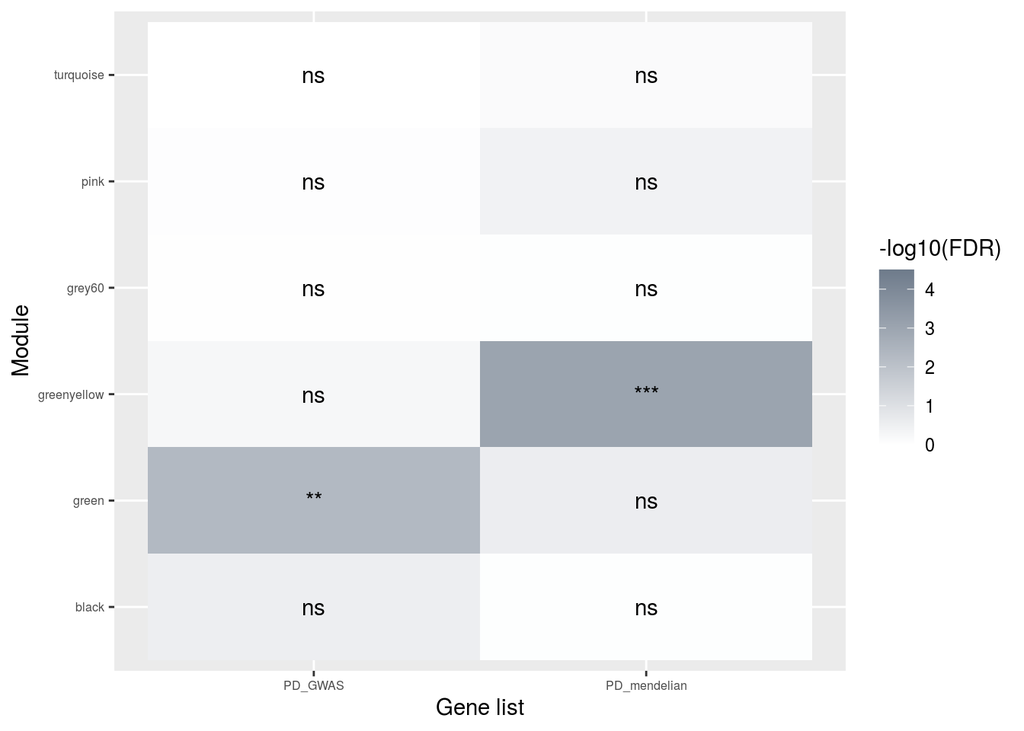

```r
# Filter repeats
OLG_melt_summ <- OLG_pvals_list %>%
  dplyr::distinct()
# Prep for figure
OLG_melt_summ$Module <- as.character(OLG_melt_summ$Module)
OLG_melt_summ$Gene_list <- as.character(OLG_melt_summ$Gene_list)
OLG_melt_summ <- dplyr::arrange(OLG_melt_summ, Module)
OLG_melt_summ$`-log10(FDR)` <- -log10(OLG_melt_summ$FDR)
# Plot
ggplot(OLG_melt_summ, aes(Gene_list, Module)) +
  geom_tile(aes(fill = `-log10(FDR)`)) +
  geom_text(aes(label = signif.num(FDR))) +
  scale_fill_gradient(low = "white", high = "lightsteelblue4", limits = c(0,4.5)) +
  labs(y = "Module", x = "Gene list") +
  theme(axis.text = element_text(size = 6))
```

# 7. Overall summary

## NSL genes

First, the overall clustering of the NSL genes was examined.

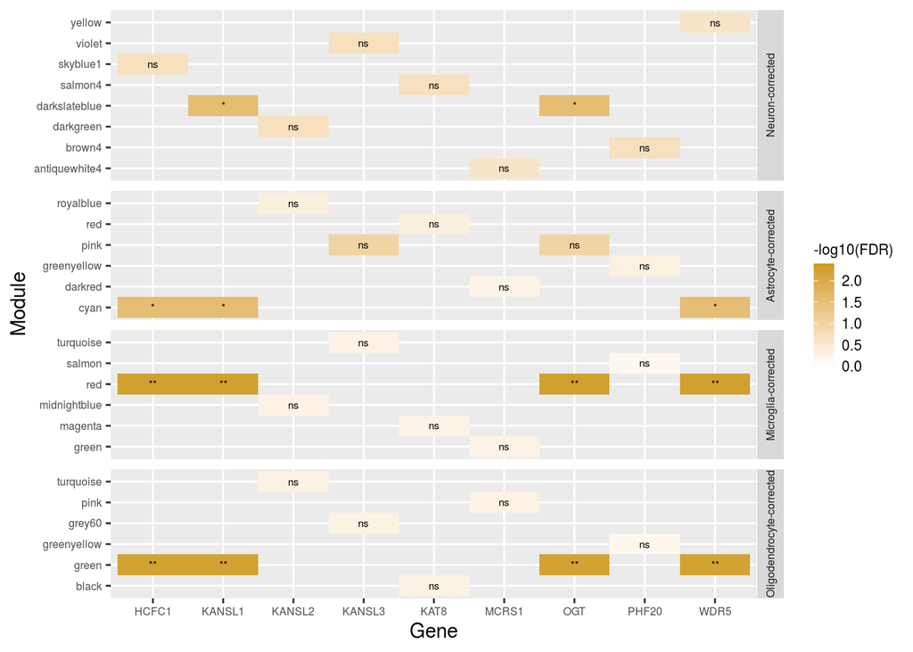

```r
# Format and join together NSL gene enrichment tables
N_NSL_mod$Network <- "Neuron-corrected"
MA_NSL_mod$Network <- "Astrocyte-corrected"
MG_NSL_mod$Network <- "Microglia-corrected"
OLG_NSL_mod$Network <- "Oligodendrocyte-corrected"
NSL_fig <- do.call(rbind, list(N_NSL_mod, MA_NSL_mod, MG_NSL_mod, OLG_NSL_mod))
NSL_fig <- dplyr::select(NSL_fig, Gene, Module, FDR, `-log10(FDR)`, Network)
# Produce plot
ggplot(NSL_fig, aes(Gene, Module)) +
  geom_tile(aes(fill = `-log10(FDR)`)) +
  geom_text(aes(label = signif.num(FDR)), size = 2) +
  scale_fill_gradient(low = "white", high = "goldenrod3", limits = c(0,2.4)) +
  labs(y = "Module", size = 4) +
  facet_grid(factor(Network,
                    levels = c("Neuron-corrected",
                               "Astrocyte-corrected",
                               "Microglia-corrected",
                               "Oligodendrocyte-corrected")) ~ .,
             scales = "free", space = "free") +
  theme(strip.text.y = element_text(angle = 90, size = 6),
        axis.text = element_text(size = 6),
        legend.title = element_text(size = 8),
        legend.text = element_text(size = 8),
        legend.key.size = unit(4, "mm"))
```

```r
# Format cell type enrichment tables (N not included as no cell type enrichments in NSL modules)
MA_mod_enrich_fig <- MA_mod_enrich_NSL %>%
  dplyr::filter_all(any_vars(.<0.05))
MA_mod_enrich_fig <- as.data.frame(t(MA_mod_enrich_fig)) %>%
  rownames_to_column(var = "Module")
MG_mod_enrich_fig <- MG_mod_enrich_NSL %>%
  dplyr::filter_all(any_vars(.<0.05))
MG_mod_enrich_fig <- as.data.frame(t(MG_mod_enrich_fig)) %>%
  rownames_to_column(var = "Module")
OLG_mod_enrich_fig <- OLG_mod_enrich_NSL %>%
  dplyr::filter_all(any_vars(.<0.05))
OLG_mod_enrich_fig <- as.data.frame(t(OLG_mod_enrich_fig)) %>%
  rownames_to_column(var = "Module")
gtex_enrich_fig <- gtex_enrich_NSL %>%
  dplyr::filter_all(any_vars(.<0.05))
gtex_enrich_fig <- as.data.frame(t(gtex_enrich_fig)) %>%
  rownames_to_column(var = "Module")
# Format NSL gene enrichment tables
MA_NSL_fig <- dplyr::select(MA_NSL_mod, Gene, Module)
MA_NSL_fig$Network <- "Astrocyte-corrected"
MG_NSL_fig <- dplyr::select(MG_NSL_mod, Gene, Module)
MG_NSL_fig$Network <- "Microglia-corrected"
OLG_NSL_fig <- dplyr::select(OLG_NSL_mod, Gene, Module)
OLG_NSL_fig$Network <- "Oligodendrocyte-corrected"
gtex_NSL_fig <- dplyr::select(NSL_rep_gt, gene, module)
names(gtex_NSL_fig)[names(gtex_NSL_fig)=="gene"] <- "Gene"
names(gtex_NSL_fig)[names(gtex_NSL_fig)== "module"] <- "Module"
gtex_NSL_fig$Network <- "None"
# Join both together
MA_NSL_figure <- dplyr::full_join(MA_mod_enrich_fig, MA_NSL_fig, by = "Module")
MA_NSL_figure <- dplyr::filter_all(MA_NSL_figure, any_vars(.<1))
MG_NSL_figure <- dplyr::full_join(MG_mod_enrich_fig, MG_NSL_fig, by = "Module")
MG_NSL_figure <- dplyr::filter_all(MG_NSL_figure, any_vars(.<1))
OLG_NSL_figure <- dplyr::full_join(OLG_mod_enrich_fig, OLG_NSL_fig, by = "Module")
OLG_NSL_figure <- dplyr::filter_all(OLG_NSL_figure, any_vars(.<1))
gtex_NSL_figure <- dplyr::full_join(gtex_enrich_fig, gtex_NSL_fig, by = "Module")
gtex_NSL_figure <- dplyr::filter_all(gtex_NSL_figure, any_vars(.<1))
big_figure <- bind_rows(MA_NSL_figure, MG_NSL_figure, OLG_NSL_figure, gtex_NSL_figure)
big_figure <- big_figure[,c(14,15,1:13,16:22)]
# Reformat and add -log10 values
big_figure2 <- tidyr::gather(big_figure, key = "Cell_type", value = "Enrichment", 4:22, -Network)
big_figure2$`-log10(p.value)` <- -log10(big_figure2$Enrichment)
big_figure2$`-log10(p.value)` <- as.numeric(big_figure2$`-log10(p.value)`)
big_figure2$`-log10(p.value)`[is.na(big_figure2$`-log10(p.value)`)] <- 0
# Remove cell types with no enrichments per network
big_figure3 <- big_figure2 %>%
  dplyr::filter(Enrichment < 1)  %>%
  dplyr::arrange(Cell_type) %>%
  dplyr::mutate(FDR = p.adjust(Enrichment, method = "fdr")) %>%
  dplyr::mutate(`-log10(FDR)` = -log10(FDR))
```

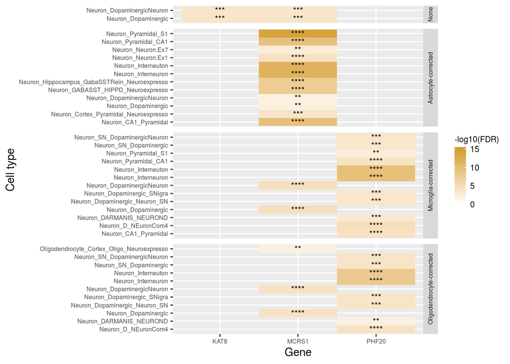

```r
# Produce plot
ggplot(big_figure3, aes(Gene, Cell_type)) +
  geom_tile(aes(fill = `-log10(FDR)`)) +
  geom_text(aes(label = signif.num2(FDR)), size = 3) +
  scale_fill_gradient(low = "white", high = "goldenrod3", limits = c(0,15.5)) +
  labs(y = "Cell type", fill = "-log10(FDR)") +
  facet_grid(factor(Network,
                    levels = c("None",
                               "Astrocyte-corrected",
                               "Microglia-corrected",
                               "Oligodendrocyte-corrected")) ~ .,
             scales = "free", space = "free") +
  theme(
    strip.text.y = element_text(angle = 90, size = 6),
    axis.text = element_text(size = 6),
    legend.title = element_text(size = 8),
    legend.text = element_text(size = 8),
    legend.key.size = unit(4, "mm"))
```

## PD genes

Second, the overall clustering of the PD associated genes was examined, focusing on modules containing *KAT8* and *KANSL1*.

```r
# Join together PD gene list enrichment tables, filter for KAT8/KANSL1 modules
N_PD_mendelian_mod2 <- N_PD_mendelian_mod1 %>%
  dplyr::mutate(List = "Mendelian PD") %>%
  dplyr::filter(module %in% c("darkslateblue", "salmon4"))
N_PD_GWAS_mod2 <- N_PD_GWAS_mod1 %>%
  dplyr::mutate(List = "Sporadic PD") %>%
  dplyr::filter(module %in% c("darkslateblue", "salmon4"))
N_PD_mod <- dplyr::bind_rows(N_PD_mendelian_mod2, N_PD_GWAS_mod2)
N_PD_mod$Network <- "Neuron-corrected"
MA_PD_mendelian_mod2 <- MA_PD_mendelian_mod1 %>%
  dplyr::mutate(List = "Mendelian PD") %>%
  dplyr::filter(module %in% c("cyan", "red"))
MA_PD_GWAS_mod2 <- MA_PD_GWAS_mod1 %>%
  dplyr::mutate(List = "Sporadic PD") %>%
  dplyr::filter(module %in% c("cyan", "red"))
MA_PD_mod <- dplyr::bind_rows(MA_PD_mendelian_mod2, MA_PD_GWAS_mod2)
MA_PD_mod$Network <- "Astrocyte-corrected"
MG_PD_mendelian_mod2 <- MG_PD_mendelian_mod1 %>%
  dplyr::mutate(List = "Mendelian PD") %>%
  dplyr::filter(module %in% c("red", "magenta"))
MG_PD_GWAS_mod2 <- MG_PD_GWAS_mod1 %>%
  dplyr::mutate(List = "Sporadic PD") %>%
  dplyr::filter(module %in% c("red", "magenta"))
MG_PD_mod <- dplyr::bind_rows(MG_PD_mendelian_mod2, MG_PD_GWAS_mod2)
MG_PD_mod$Network <- "Microglia-corrected"
OLG_PD_mendelian_mod2 <- OLG_PD_mendelian_mod1 %>%
  dplyr::mutate(List = "Mendelian PD") %>%
  dplyr::filter(module %in% c("green", "black"))
OLG_PD_GWAS_mod2 <- OLG_PD_GWAS_mod1 %>%
  dplyr::mutate(List = "Sporadic PD") %>%
  dplyr::filter(module %in% c("green", "black"))
OLG_PD_mod <- dplyr::bind_rows(OLG_PD_mendelian_mod2, OLG_PD_GWAS_mod2)
OLG_PD_mod$Network <- "Oligodendrocyte-corrected"
# Join all 4 network results into one table
PD_fig <- do.call(rbind, list(N_PD_mod, MA_PD_mod, MG_PD_mod, OLG_PD_mod))
PD_fig$`-log10(FDR)` <- -log10(PD_fig$FDR)
PD_fig <- dplyr::select(PD_fig, List, module, FDR, `-log10(FDR)`, Network)
# Add in empty row for 'salmon4' module so it lines up with NSL figure
PD_fig <- rbind(PD_fig, c("zzz", "salmon4", 1, 1, "Neuron-corrected"))
PD_fig$`-log10(FDR)` <- as.numeric(PD_fig$`-log10(FDR)`)
PD_fig$FDR <- as.numeric(PD_fig$FDR)
# Alter names
PD_fig$module[PD_fig$module=="salmon4"] <- "salmon4 (KAT8)"
PD_fig$module[PD_fig$module=="darkslateblue"] <- "darkslateblue (KANSL1)"
PD_fig$module[PD_fig$module=="red" & PD_fig$Network == "Astrocyte-corrected"] <- "red (KAT8)"
PD_fig$module[PD_fig$module=="cyan"] <- "cyan (KANSL1)"
PD_fig$module[PD_fig$module=="magenta"] <- "magenta (KAT8)"
PD_fig$module[PD_fig$module=="red"& PD_fig$Network == "Microglia-corrected"] <- "red (KANSL1)"
PD_fig$module[PD_fig$module=="green"] <- "green (KANSL1)"
PD_fig$module[PD_fig$module=="black"] <- "black (KAT8)"
```

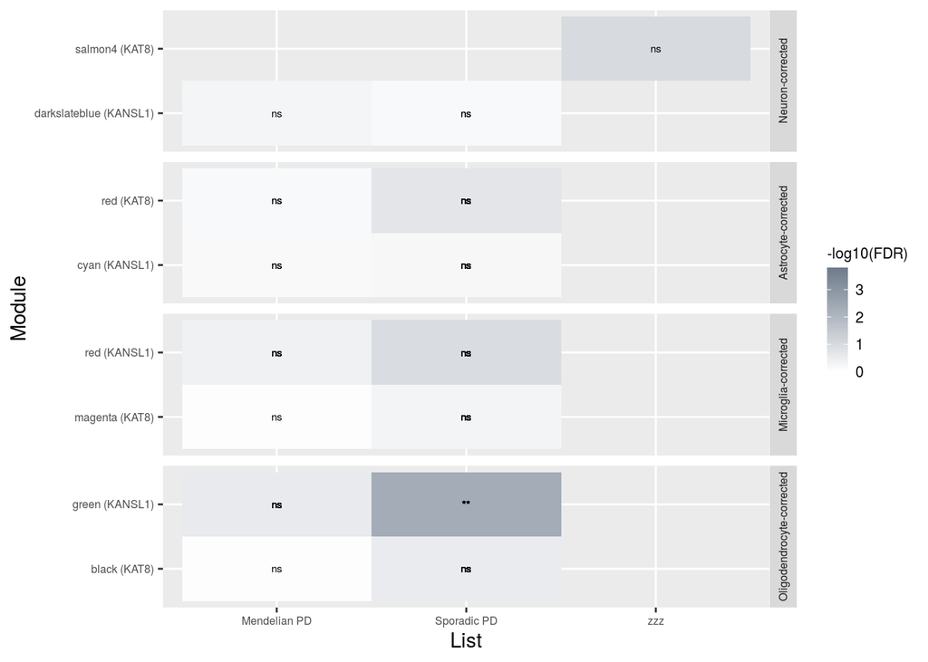

```r
# Produce plot
ggplot(PD_fig, aes(List, module)) +
  geom_tile(aes(fill = `-log10(FDR)`)) +
  geom_text(aes(label = signif.num(FDR)), size = 2) +
  scale_fill_gradient(low = "white", high = "lightsteelblue4", limits = c(0,3.8)) +
  labs(y = "Module", size = 4) +
  facet_grid(factor(Network,
                    levels = c("Neuron-corrected",
                               "Astrocyte-corrected",
                               "Microglia-corrected",
                               "Oligodendrocyte-corrected")) ~ .,
             scales = "free", space = "free") +
  theme(
    strip.text.y = element_text(angle = 90, size = 6),
    axis.text = element_text(size = 6),
    legend.title = element_text(size = 8),
    legend.text = element_text(size = 8),
    legend.key.size = unit(4, "mm"))
```

```r
# Format PD list enrichment tables
MA_PD_fig <- MA_PD_mod %>%
  dplyr::select(List, module, Network) %>%
  dplyr::rename(Module = module)
MG_PD_fig <- MG_PD_mod %>%
  dplyr::select(List, module, Network) %>%
  dplyr::rename(Module = module)
OLG_PD_fig <- OLG_PD_mod %>%
  dplyr::select(List, module, Network) %>%
  dplyr::rename(Module = module)
PD_mendelian_rep$List <- "Mendelian PD"
PD_GWAS_rep$List <- "Sporadic PD"
prim_PD_rep <- bind_rows(PD_mendelian_rep, PD_GWAS_rep)
gtex_PD_fig <- dplyr::select(prim_PD_rep, List, module)
gtex_PD_fig$Network <- "None"
gtex_PD_fig <- gtex_PD_fig %>% dplyr::rename(Module = module)
# Filter cell type enrichment tables for only modules PD genes appear in
MA_mod_enrich_PD <- MA_mod_enrich %>%
  dplyr::select(one_of(MA_PD_mendelian_mod1$module)) %>%
  dplyr::filter_all(any_vars(.<0.05))
MA_mod_enrich_PD <- as.data.frame(t(MA_mod_enrich_PD)) %>%
  rownames_to_column(var = "Module")
MG_mod_enrich_PD <- MG_mod_enrich %>%
  dplyr::select(one_of(MG_PD_mendelian_mod1$module)) %>%
  dplyr::filter_all(any_vars(.<0.05))
MG_mod_enrich_PD <- as.data.frame(t(MG_mod_enrich_PD)) %>%
  rownames_to_column(var = "Module")
OLG_mod_enrich_PD <- OLG_mod_enrich %>%
  dplyr::select(one_of(OLG_PD_mendelian_mod1$module)) %>%
  dplyr::filter_all(any_vars(.<0.05))
OLG_mod_enrich_PD <- as.data.frame(t(OLG_mod_enrich_PD)) %>%
  rownames_to_column(var = "Module")
gtex_enrich_PD <- gtex_enrich %>%
  dplyr::select(one_of(gtex_PD_fig$Module)) %>%
  dplyr::filter_all(any_vars(.<0.05))
gtex_enrich_PD <- as.data.frame(t(gtex_enrich_PD)) %>%
  rownames_to_column(var = "Module")
# Join together
MA_PD_figure <- dplyr::full_join(MA_mod_enrich_PD, MA_PD_fig, by = "Module")
MA_PD_figure <- dplyr::filter_all(MA_PD_figure, any_vars(.<1))
MG_PD_figure <- dplyr::full_join(MG_mod_enrich_PD, MG_PD_fig, by = "Module")
MG_PD_figure <- dplyr::filter_all(MG_PD_figure, any_vars(.<1))
OLG_PD_figure <- dplyr::full_join(OLG_mod_enrich_PD, OLG_PD_fig, by = "Module")
OLG_PD_figure <- dplyr::filter_all(OLG_PD_figure, any_vars(.<1))
gtex_PD_figure <- dplyr::full_join(gtex_enrich_PD, gtex_PD_fig, by = "Module")
gtex_PD_figure <- dplyr::filter_all(gtex_PD_figure, any_vars(.<1))
big_PDfigure <- bind_rows(MA_PD_figure, MG_PD_figure, OLG_PD_figure, gtex_PD_figure)
big_PDfigure <- big_PDfigure[,c(14,15,1:13,16:22)]
# Reformat
big_PDfigure2 <- tidyr::gather(big_PDfigure, key = "Cell_type", value = "Enrichment", 4:22, -Network)
big_PDfigure2$`-log10(p.value)` <- -log10(big_PDfigure2$Enrichment)
big_PDfigure2$`-log10(p.value)` <- as.numeric(big_PDfigure2$`-log10(p.value)`)
big_PDfigure2$`-log10(p.value)`[is.na(big_PDfigure2$`-log10(p.value)`)] <- 0
# Remove cell types with no enrichments per network
big_PDfigure3 <- big_PDfigure2 %>%
  dplyr::filter(Enrichment < 1)  %>%
  dplyr::arrange(Cell_type)
```

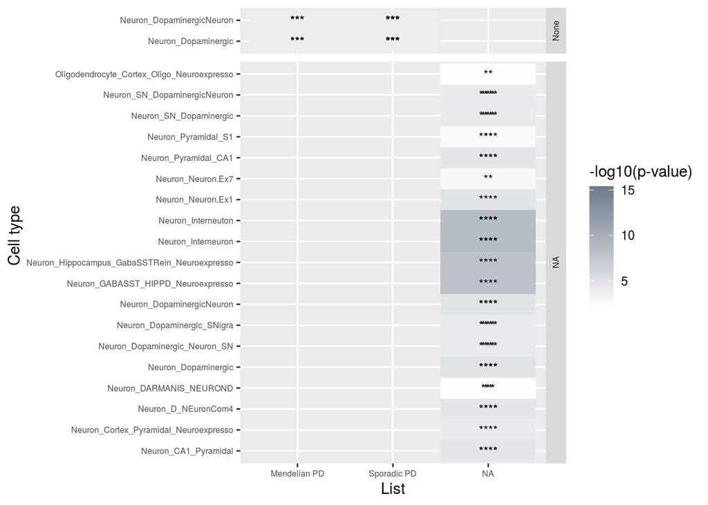

```r
# Produce plot
ggplot(big_PDfigure3, aes(List, Cell_type)) +
  geom_tile(aes(fill = `-log10(p.value)`)) +
  geom_text(aes(label = signif.num2(Enrichment)), size = 3) +
  scale_fill_gradient(low = "white", high = "lightsteelblue4") +
  labs(y = "Cell type", fill = "-log10(p-value)") +
  facet_grid(factor(Network,
                    levels = c("None",
                               "Astrocyte-corrected",
                               "Microglia-corrected",
                               "Oligodendrocyte-corrected")) ~ .,
             scales = "free", space = "free") +
  theme(strip.text.y = element_text(angle = 90, size = 6), axis.text = element_text(size = 6))
```